# Tugas Pertemuan 1

## 4.1 Eksplorasi Data Latih dan Data Uji

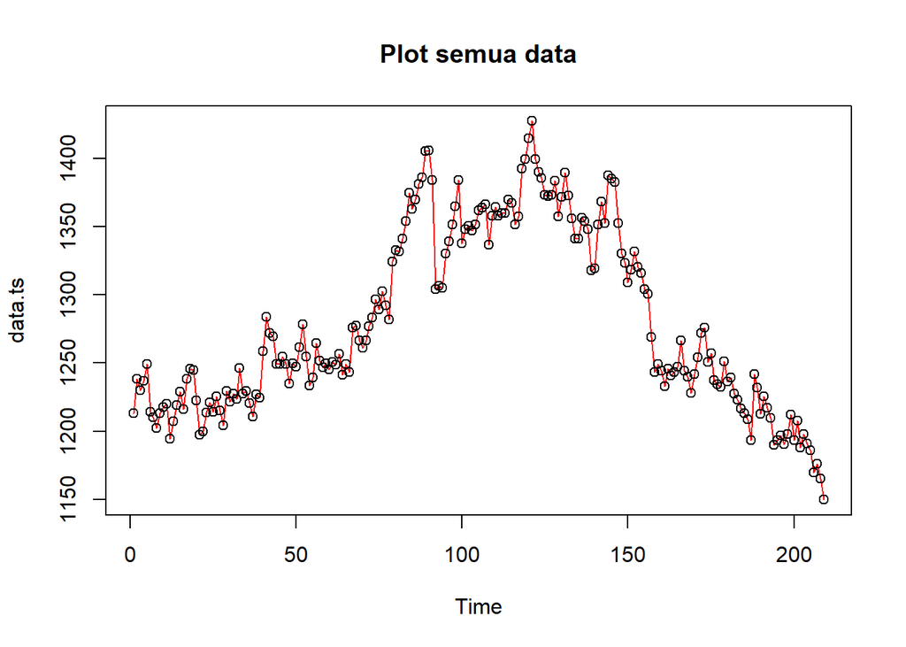

```r
plot(data.ts, col="red",main="Plot semua data")
points(data.ts)
```

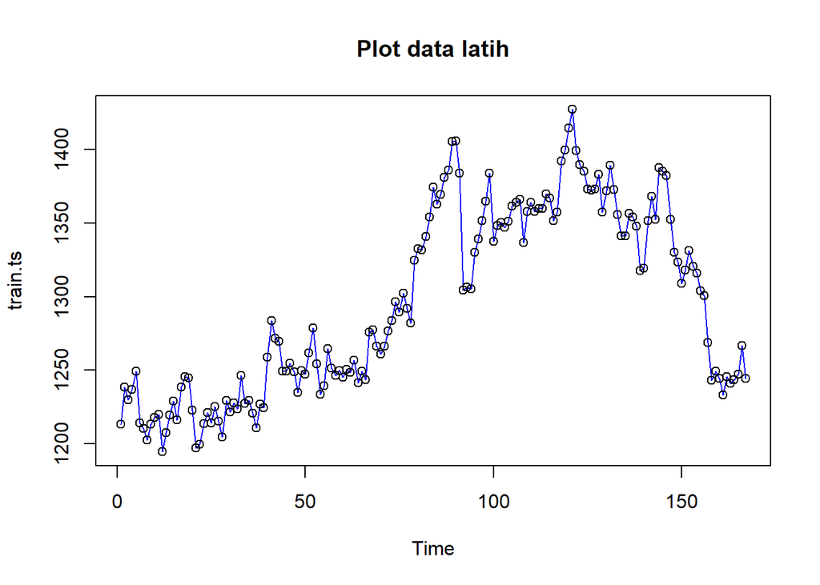

```r
plot(train.ts, col="blue",main="Plot data latih")
points(train.ts)
```

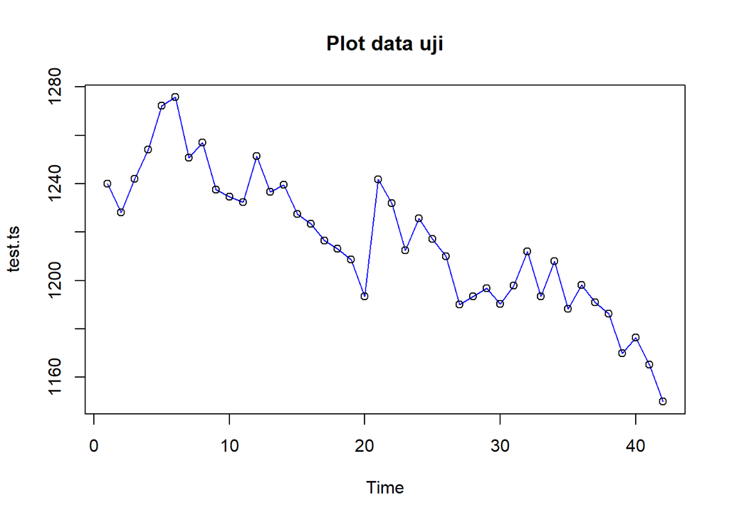

```r
plot(test.ts, col="blue",main="Plot data uji")
points(test.ts)
```

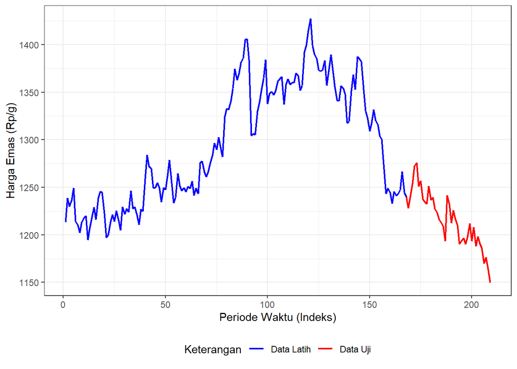

```r
train_df <- data.frame(
  Index = 1:length(train.ts),
  Harga = as.numeric(train.ts),
  status = "Data Latih"
)

test_df <- data.frame(
  Index = (length(train.ts) + 1):(length(train.ts) + length(test.ts)),
  Harga = as.numeric(test.ts),
  status = "Data Uji"
)

data_all <- rbind(train_df, test_df)

ggplot(data_all, aes(x = Index, y = Harga, color = status, group = 1)) +
  geom_line(size = 0.8) +
  labs(x = "Periode Waktu (Indeks)", y = "Harga Emas (Rp/g)", color = "Keterangan") +
  scale_color_manual(values = c("Data Latih" = "blue", "Data Uji" = "red")) +
  theme_bw() +
  theme(legend.position = "bottom")
```

# 5 Pemulusan

## 5.1 Single Moving Average (SMA)

```r
data.sma<-SMA(train.ts, n=4)
data.sma
```

```
## Time Series:
## Start = 1
## End = 167
## Frequency = 1
##   [1]       NA       NA       NA 1229.555 1238.633 1232.503 1227.628 1219.035
##   [9] 1210.007 1210.947 1213.367 1211.420 1209.922 1210.305 1212.575 1217.975
##  [17] 1225.747 1232.327 1236.182 1237.802 1227.520 1216.035 1208.335 1207.975
##  [25] 1212.187 1218.620 1219.002 1214.845 1218.697 1217.762 1220.845 1225.610
##  [33] 1229.797 1231.252 1231.670 1230.912 1222.065 1221.920 1220.720 1230.280
##  [41] 1248.522 1259.725 1271.007 1268.620 1259.985 1255.742 1250.595 1246.967
##  [49] 1247.062 1245.217 1248.377 1259.337 1260.530 1257.032 1251.442 1247.927
##  [57] 1247.207 1250.495 1253.082 1248.252 1248.032 1248.565 1250.310 1249.395
##  [65] 1249.002 1247.665 1252.462 1261.470 1265.765 1270.210 1267.852 1267.627
##  [73] 1271.935 1280.802 1286.555 1292.987 1295.130 1291.455 1300.230 1307.797
##  [81] 1317.722 1332.495 1339.882 1350.355 1358.072 1365.207 1371.987 1374.805
##  [89] 1385.480 1394.602 1395.330 1374.942 1350.235 1325.027 1311.550 1320.242
##  [97] 1331.480 1346.425 1359.887 1359.530 1358.695 1355.092 1345.850 1349.282
## [105] 1352.660 1355.995 1360.800 1357.165 1356.252 1356.325 1354.227 1359.970
## [113] 1360.420 1361.845 1364.150 1362.117 1361.495 1367.075 1375.177 1390.885
## [121] 1408.377 1410.137 1407.687 1400.405 1386.885 1380.142 1376.030 1375.512
## [129] 1371.540 1371.435 1375.465 1372.840 1372.502 1364.862 1352.782 1348.732
## [137] 1348.272 1349.952 1344.092 1334.745 1334.130 1339.190 1347.940 1365.037
## [145] 1373.402 1376.932 1376.910 1362.505 1347.050 1328.750 1320.157 1320.547
## [153] 1319.847 1321.567 1317.995 1310.255 1297.337 1279.120 1265.420 1251.350
## [161] 1242.422 1243.025 1240.990 1240.755 1244.247 1249.480 1250.300
```

```r
data.ramal<-c(NA,data.sma)
data.ramal
```

```
##   [1]       NA       NA       NA       NA 1229.555 1238.633 1232.503 1227.628
##   [9] 1219.035 1210.007 1210.947 1213.367 1211.420 1209.922 1210.305 1212.575
##  [17] 1217.975 1225.747 1232.327 1236.182 1237.802 1227.520 1216.035 1208.335
##  [25] 1207.975 1212.187 1218.620 1219.002 1214.845 1218.697 1217.762 1220.845
##  [33] 1225.610 1229.797 1231.252 1231.670 1230.912 1222.065 1221.920 1220.720
##  [41] 1230.280 1248.522 1259.725 1271.007 1268.620 1259.985 1255.742 1250.595
##  [49] 1246.967 1247.062 1245.217 1248.377 1259.337 1260.530 1257.032 1251.442
##  [57] 1247.927 1247.207 1250.495 1253.082 1248.252 1248.032 1248.565 1250.310
##  [65] 1249.395 1249.002 1247.665 1252.462 1261.470 1265.765 1270.210 1267.852
##  [73] 1267.627 1271.935 1280.802 1286.555 1292.987 1295.130 1291.455 1300.230
##  [81] 1307.797 1317.722 1332.495 1339.882 1350.355 1358.072 1365.207 1371.987
##  [89] 1374.805 1385.480 1394.602 1395.330 1374.942 1350.235 1325.027 1311.550
##  [97] 1320.242 1331.480 1346.425 1359.887 1359.530 1358.695 1355.092 1345.850
## [105] 1349.282 1352.660 1355.995 1360.800 1357.165 1356.252 1356.325 1354.227
## [113] 1359.970 1360.420 1361.845 1364.150 1362.117 1361.495 1367.075 1375.177
## [121] 1390.885 1408.377 1410.137 1407.687 1400.405 1386.885 1380.142 1376.030
## [129] 1375.512 1371.540 1371.435 1375.465 1372.840 1372.502 1364.862 1352.782
## [137] 1348.732 1348.272 1349.952 1344.092 1334.745 1334.130 1339.190 1347.940
## [145] 1365.037 1373.402 1376.932 1376.910 1362.505 1347.050 1328.750 1320.157
## [153] 1320.547 1319.847 1321.567 1317.995 1310.255 1297.337 1279.120 1265.420
## [161] 1251.350 1242.422 1243.025 1240.990 1240.755 1244.247 1249.480 1250.300
```

```r
n_test<-length(test.ts)
data.gab<-cbind(
  aktual=c(data.ts),
  pemulusan=c(data.sma,rep(NA,n_test)),
  ramalan=c(data.ramal,rep(data.ramal[length(data.ramal)],41)))

data.gab
```

```
##         aktual pemulusan  ramalan
##   [1,] 1213.07        NA       NA
##   [2,] 1238.55        NA       NA
##   [3,] 1229.90        NA       NA
##   [4,] 1236.70  1229.555       NA
##   [5,] 1249.38  1238.633 1229.555
##   [6,] 1214.03  1232.503 1238.633
##   [7,] 1210.40  1227.628 1232.503
##   [8,] 1202.33  1219.035 1227.628
##   [9,] 1213.27  1210.007 1219.035
##  [10,] 1217.79  1210.947 1210.007
##  [11,] 1220.08  1213.367 1210.947
##  [12,] 1194.54  1211.420 1213.367
##  [13,] 1207.28  1209.922 1211.420
##  [14,] 1219.32  1210.305 1209.922
```

[output cut: 195 more lines]

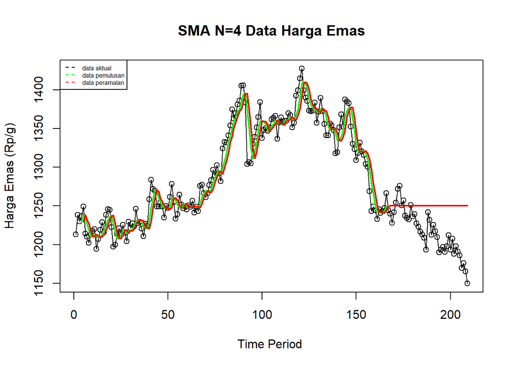

```r
ts.plot(data.ts, xlab="Time Period ", ylab="Harga Emas (Rp/g)", main= "SMA N=4 Data Harga Emas")
points(data.ts)
lines(data.gab[,2],col="green",lwd=2)
lines(data.gab[,3],col="red",lwd=2)
legend("topleft",c("data aktual","data pemulusan","data peramalan"), lty=8, col=c("black","green","red"), cex=0.5)
```

### 5.1.1 Akurasi Data Latih

```r
error_train.sma <- train.ts - data.ramal[1:length(train.ts)]
idx_sma <- 5:length(train.ts)

SSE_train.sma <- sum(error_train.sma[idx_sma]^2)
MSE_train.sma <- mean(error_train.sma[idx_sma]^2)
MAPE_train.sma <- mean(abs((error_train.sma[idx_sma] / train.ts[idx_sma]) * 100))

akurasi_train.sma <- matrix(c(SSE_train.sma, MSE_train.sma, MAPE_train.sma))
row.names(akurasi_train.sma) <- c("SSE", "MSE", "MAPE")
colnames(akurasi_train.sma) <- c("Akurasi m = 4")
akurasi_train.sma
```

```
##      Akurasi m = 4
## SSE   77276.105263
## MSE     474.086535
## MAPE      1.274026
```

### 5.1.2 Akurasi Data Uji

```r
ramalan_test.sma <- data.gab[(n_train + 1):n, 3]
error_test.sma <- test.ts - ramalan_test.sma

SSE_test.sma <- sum(error_test.sma^2)
MSE_test.sma <- mean(error_test.sma^2)
MAPE_test.sma <- mean(abs((error_test.sma / test.ts) * 100))

akurasi_test.sma <- matrix(c(SSE_test.sma, MSE_test.sma, MAPE_test.sma))
row.names(akurasi_test.sma) <- c("SSE", "MSE", "MAPE")
colnames(akurasi_test.sma) <- c("Akurasi m = 4")
akurasi_test.sma
```

```
##      Akurasi m = 4
## SSE   82822.696700
## MSE    1971.968969
## MAPE      3.083589
```

## 5.2 Double Moving Average (DMA)

```r
n_test <- length(test.ts)

data.sma <- SMA(train.ts, n = 4)
data.dma <- SMA(data.sma, n = 4)
At <- 2 * data.sma - data.dma
Bt <- (2 / (4 - 1)) * (data.sma - data.dma)

data.pemulusan <- At + Bt

data.ramal <- c(NA, data.pemulusan)

f <- At[length(At)] + Bt[length(Bt)] * (1:(n_test-1))

data.gab.dma <- cbind(
  aktual = c(data.ts),
  pemulusan = c(data.pemulusan, rep(NA, n_test)),
  ramalan = c(data.ramal, f)
)
data.gab.dma
```

```
##         aktual pemulusan  ramalan
##   [1,] 1213.07        NA       NA
##   [2,] 1238.55        NA       NA
##   [3,] 1229.90        NA       NA
##   [4,] 1236.70        NA       NA
##   [5,] 1249.38        NA       NA
##   [6,] 1214.03        NA       NA
##   [7,] 1210.40  1220.208       NA
##   [8,] 1202.33  1201.678 1220.208
##   [9,] 1213.27  1189.531 1201.678
##  [10,] 1217.79  1201.019 1189.531
##  [11,] 1220.08  1213.414 1201.019
##  [12,] 1194.54  1211.394 1213.414
##  [13,] 1207.28  1207.436 1211.394
##  [14,] 1219.32  1208.724 1207.436
```

[output cut: 195 more lines]

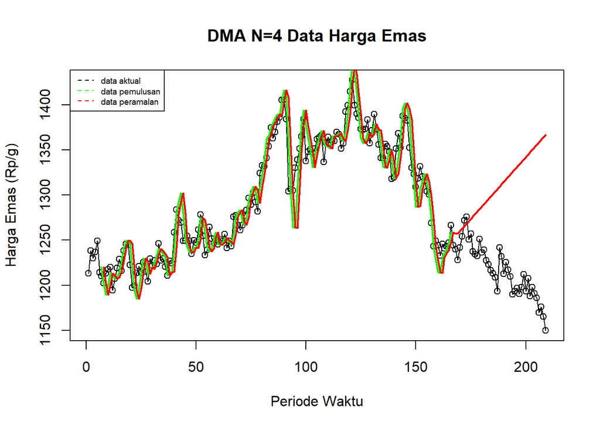

```r
ts.plot(data.ts, xlab="Periode Waktu", ylab="Harga Emas (Rp/g)", main= "DMA N=4 Data Harga Emas")
points(data.ts)
lines(data.gab.dma[,2],col="green",lwd=2)
lines(data.gab.dma[,3],col="red",lwd=2)
legend("topleft",c("data aktual","data pemulusan","data peramalan"), lty=8, col=c("black","green","red"), cex=0.6)
```

### 5.2.1 Akurasi Data Latih

```r
error_train.dma <- as.numeric(train.ts) - data.ramal[1:length(train.ts)]

idx_dma <- 8:length(train.ts)

SSE_train.dma <- sum(error_train.dma[idx_dma]^2, na.rm = TRUE)
MSE_train.dma <- mean(error_train.dma[idx_dma]^2, na.rm = TRUE)
MAPE_train.dma <- mean(abs((error_train.dma[idx_dma] / as.numeric(train.ts)[idx_dma]) * 100), na.rm = TRUE)

akurasi_train.dma <- matrix(c(SSE_train.dma, MSE_train.dma, MAPE_train.dma))
row.names(akurasi_train.dma) <- c("SSE", "MSE", "MAPE")
colnames(akurasi_train.dma) <- c("Akurasi m = 4")
akurasi_train.dma
```

```
##      Akurasi m = 4
## SSE   93713.048505
## MSE     585.706553
## MAPE      1.430832
```

### 5.2.2 Akurasi Data Uji

```r
ramalan_test.dma <- as.numeric(data.gab.dma[(n_train + 1):n, 3])
aktual_test.dma <- as.numeric(test.ts)

error_test.dma <- aktual_test.dma - ramalan_test.dma

SSE_test.dma <- sum(error_test.dma^2, na.rm = TRUE)
MSE_test.dma <- mean(error_test.dma^2, na.rm = TRUE)
MAPE_test.dma <- mean(abs((error_test.dma / aktual_test.dma) * 100), na.rm = TRUE)

akurasi_test.dma <- matrix(c(SSE_test.dma, MSE_test.dma, MAPE_test.dma))
row.names(akurasi_test.dma) <- c("SSE", "MSE", "MAPE")
colnames(akurasi_test.dma) <- c("Akurasi m = 4")
akurasi_test.dma
```

```
##      Akurasi m = 4
## SSE   5.239207e+05
## MSE   1.247430e+04
## MAPE  7.929323e+00
```

## 5.3 Single Exponential Smoothing

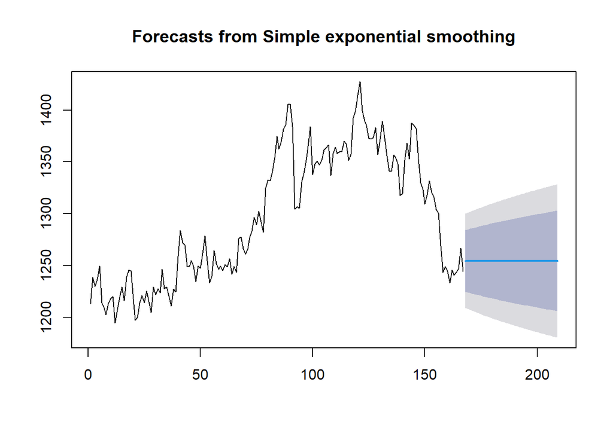

```r
ses1 <- ses(train.ts, h = 42, alpha = 0.2)
plot(ses1)
```

```r
ses1
```

```
##     Point Forecast    Lo 80    Hi 80    Lo 95    Hi 95
## 168       1254.464 1224.690 1284.238 1208.928 1300.000
## 169       1254.464 1224.100 1284.828 1208.026 1300.902
## 170       1254.464 1223.522 1285.406 1207.142 1301.786
## 171       1254.464 1222.954 1285.974 1206.273 1302.655
## 172       1254.464 1222.396 1286.532 1205.420 1303.508
## 173       1254.464 1221.848 1287.080 1204.582 1304.346
## 174       1254.464 1221.309 1287.619 1203.758 1305.171
## 175       1254.464 1220.778 1288.150 1202.946 1305.982
## 176       1254.464 1220.256 1288.672 1202.147 1306.781
## 177       1254.464 1219.742 1289.186 1201.361 1307.567
## 178       1254.464 1219.235 1289.693 1200.585 1308.343
## 179       1254.464 1218.735 1290.193 1199.821 1309.107
## 180       1254.464 1218.242 1290.686 1199.067 1309.861
## 181       1254.464 1217.756 1291.172 1198.324 1310.604
```

[output cut: 28 more lines]

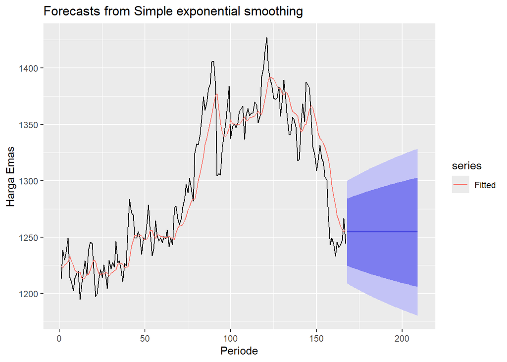

```r
autoplot(ses1) +
  autolayer(fitted(ses1), series="Fitted") +
  ylab("Harga Emas") + xlab("Periode")
```

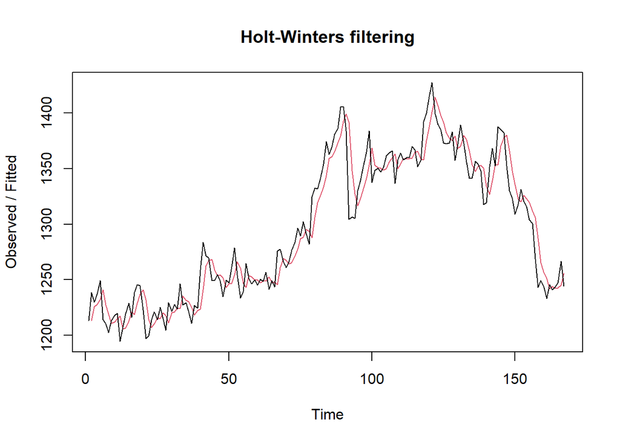

```r
ses2<- HoltWinters(train.ts, gamma = FALSE, beta = FALSE, alpha = 0.5)
plot(ses2)
```

```r
ramalan<- forecast(ses2, h=42)
ramalan
```

```
##     Point Forecast    Lo 80    Hi 80    Lo 95    Hi 95
## 168       1249.991 1226.397 1273.585 1213.907 1286.075
## 169       1249.991 1223.612 1276.370 1209.648 1290.335
## 170       1249.991 1221.094 1278.888 1205.797 1294.185
## 171       1249.991 1218.779 1281.203 1202.256 1297.726
## 172       1249.991 1216.624 1283.359 1198.960 1301.022
## 173       1249.991 1214.600 1285.383 1195.865 1304.118
## 174       1249.991 1212.685 1287.297 1192.937 1307.045
## 175       1249.991 1210.865 1289.118 1190.152 1309.830
## 176       1249.991 1209.125 1290.858 1187.491 1312.491
## 177       1249.991 1207.456 1292.526 1184.939 1315.043
## 178       1249.991 1205.850 1294.132 1182.484 1317.499
## 179       1249.991 1204.301 1295.681 1180.114 1319.868
## 180       1249.991 1202.803 1297.180 1177.823 1322.160
## 181       1249.991 1201.351 1298.632 1175.602 1324.381
```

[output cut: 28 more lines]

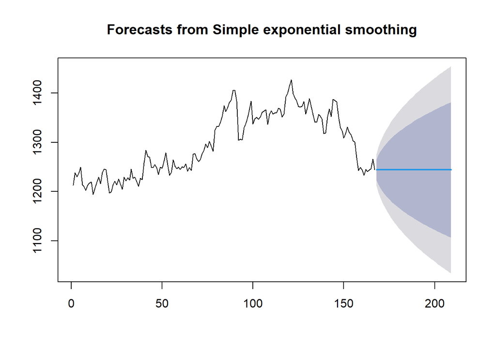

```r
ses.opt <- ses(train.ts, h = 42, alpha = NULL)
plot(ses.opt)
```

```r
ses.opt
```

```
##     Point Forecast    Lo 80    Hi 80    Lo 95    Hi 95
## 168       1244.242 1222.998 1265.486 1211.752 1276.732
## 169       1244.242 1214.200 1274.284 1198.297 1290.187
## 170       1244.242 1207.449 1281.035 1187.972 1300.512
## 171       1244.242 1201.758 1286.727 1179.268 1309.217
## 172       1244.242 1196.743 1291.741 1171.599 1316.886
## 173       1244.242 1192.210 1296.275 1164.665 1323.819
## 174       1244.242 1188.041 1300.444 1158.290 1330.195
## 175       1244.242 1184.161 1304.324 1152.355 1336.129
## 176       1244.242 1180.516 1307.968 1146.782 1341.703
## 177       1244.242 1177.069 1311.415 1141.510 1346.975
## 178       1244.242 1173.791 1314.694 1136.496 1351.989
## 179       1244.242 1170.658 1317.827 1131.705 1356.780
## 180       1244.242 1167.653 1320.831 1127.109 1361.375
## 181       1244.242 1164.762 1323.722 1122.688 1365.797
```

[output cut: 28 more lines]

```r
HWopt<- HoltWinters(train.ts, gamma = FALSE, beta = FALSE,alpha = NULL)
HWopt
```

```
## Holt-Winters exponential smoothing without trend and without seasonal component.
##
## Call:
## HoltWinters(x = train.ts, alpha = NULL, beta = FALSE, gamma = FALSE)
##
## Smoothing parameters:
##  alpha: 0.9999511
##  beta : FALSE
##  gamma: FALSE
##
## Coefficients:
##       [,1]
## a 1244.241
```

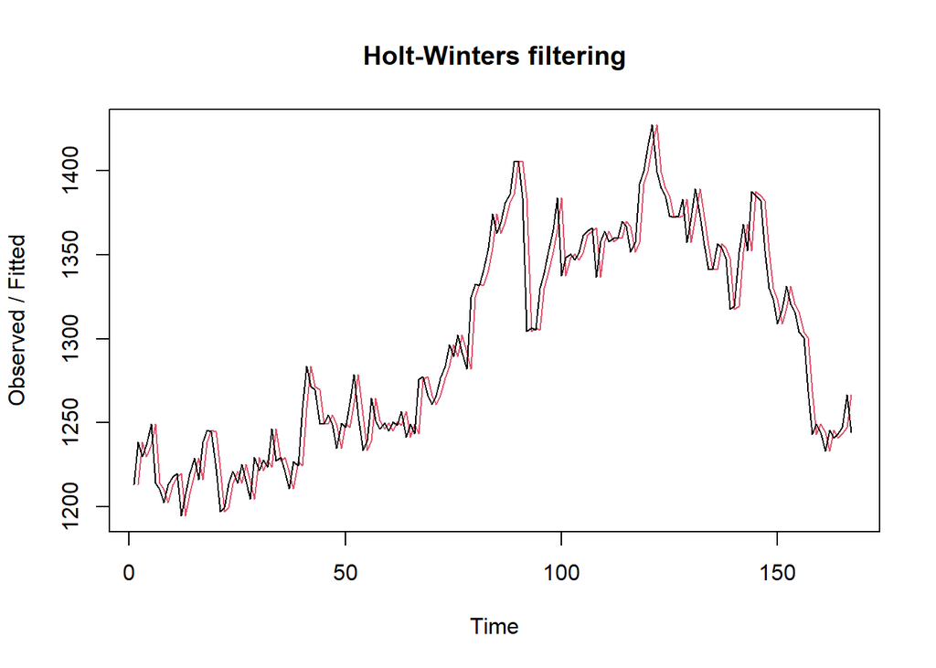

```r
plot(HWopt)
```

```r
ramalanopt<- forecast(HWopt, h=42)
ramalanopt
```

```
##     Point Forecast    Lo 80    Hi 80    Lo 95    Hi 95
## 168       1244.241 1222.999 1265.484 1211.753 1276.729
## 169       1244.241 1214.200 1274.282 1198.298 1290.184
## 170       1244.241 1207.449 1281.033 1187.973 1300.510
## 171       1244.241 1201.758 1286.725 1179.268 1309.214
## 172       1244.241 1196.743 1291.739 1171.599 1316.883
## 173       1244.241 1192.210 1296.272 1164.666 1323.816
## 174       1244.241 1188.041 1300.441 1158.290 1330.192
## 175       1244.241 1184.161 1304.322 1152.356 1336.126
## 176       1244.241 1180.516 1307.966 1146.782 1341.700
## 177       1244.241 1177.069 1311.413 1141.511 1346.972
## 178       1244.241 1173.791 1314.692 1136.496 1351.986
## 179       1244.241 1170.658 1317.824 1131.706 1356.777
## 180       1244.241 1167.653 1320.829 1127.110 1361.372
## 181       1244.241 1164.762 1323.720 1122.689 1365.793
```

[output cut: 28 more lines]

### 5.3.1 Akurasi Data Latih (HWopt)

```r
SSE<-HWopt$SSE
MSE<-HWopt$SSE/length(train.ts)
RMSE<-sqrt(MSE)

akurasi <- matrix(c(SSE,MSE,RMSE))
row.names(akurasi)<- c("SSE", "MSE", "RMSE")
colnames(akurasi) <- c("Akurasi Data Latih (HWopt)")
akurasi
```

```
##      Akurasi Data Latih (HWopt)
## SSE                 45339.96268
## MSE                   271.49678
## RMSE                   16.47716
```

```r
SSE <- HWopt$SSE
MSE <- HWopt$SSE / length(train.ts)
RMSE <- sqrt(MSE)

fitted <- as.numeric(HWopt$fitted[, 1])[1:length(train.ts)]
error_train <- as.numeric(train.ts) - fitted
MAPE <- mean(abs((error_train / as.numeric(train.ts)) * 100), na.rm = TRUE)

akurasi <- matrix(c(SSE, MSE, RMSE, MAPE), nrow = 4)
row.names(akurasi) <- c("SSE", "MSE", "RMSE", "MAPE")
colnames(akurasi) <- c("Akurasi Data Latih (HWopt)")
akurasi
```

```
##      Akurasi Data Latih (HWopt)
## SSE                4.533996e+04
## MSE                2.714968e+02
## RMSE               1.647716e+01
## MAPE               4.685727e-05
```

### 5.3.2 Akurasi Data Uji (HWopt)

```r
ramalan_test <- as.numeric(ramalanopt$mean)
error_test <- as.numeric(test.ts) - ramalan_test

SSE_test <- sum(error_test^2, na.rm = TRUE)
MSE_test <- mean(error_test^2, na.rm = TRUE)
RMSE_test <- sqrt(MSE_test)
MAPE_test <- mean(abs((error_test / as.numeric(test.ts)) * 100), na.rm = TRUE)

akurasi_test <- matrix(c(SSE_test, MSE_test, RMSE_test, MAPE_test), nrow = 4)
row.names(akurasi_test) <- c("SSE", "MSE", "RMSE", "MAPE")
colnames(akurasi_test) <- c("Akurasi Testing (HWopt)")
akurasi_test
```

```
##      Akurasi Testing (HWopt)
## SSE             67004.662433
## MSE              1595.349106
## RMSE               39.941822
## MAPE                2.722506
```

## 5.4 Double Exponential Smoothing (DES)

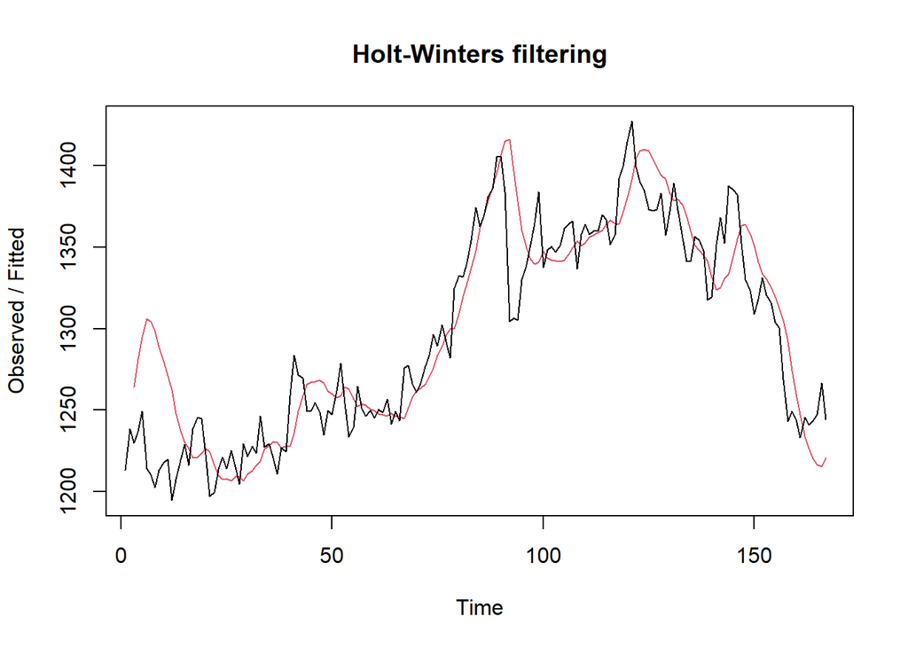

```r
des.1<- HoltWinters(train.ts, gamma = FALSE, beta = 0.2, alpha = 0.2)
plot(des.1)
```

```r
ramalandes1<- forecast(des.1, h=42)
ramalandes1
```

```
##     Point Forecast     Lo 80    Hi 80     Lo 95    Hi 95
## 168       1221.253 1184.4888 1258.017 1165.0269 1277.479
## 169       1217.139 1179.3310 1254.948 1159.3165 1274.962
## 170       1213.026 1173.8410 1252.210 1153.0979 1272.953
## 171       1208.912 1167.9993 1249.825 1146.3415 1271.482
## 172       1204.798 1161.7980 1247.798 1139.0351 1270.561
## 173       1200.684 1155.2392 1246.130 1131.1819 1270.187
## 174       1196.571 1148.3323 1244.809 1122.7965 1270.345
## 175       1192.457 1141.0921 1243.822 1113.9011 1271.013
## 176       1188.343 1133.5360 1243.150 1104.5228 1272.164
## 177       1184.230 1125.6830 1242.776 1094.6903 1273.769
## 178       1180.116 1117.5516 1242.680 1084.4321 1275.799
## 179       1176.002 1109.1597 1242.844 1073.7755 1278.229
## 180       1171.888 1100.5238 1243.253 1062.7458 1281.031
## 181       1167.775 1091.6591 1243.890 1051.3660 1284.183
```

[output cut: 28 more lines]

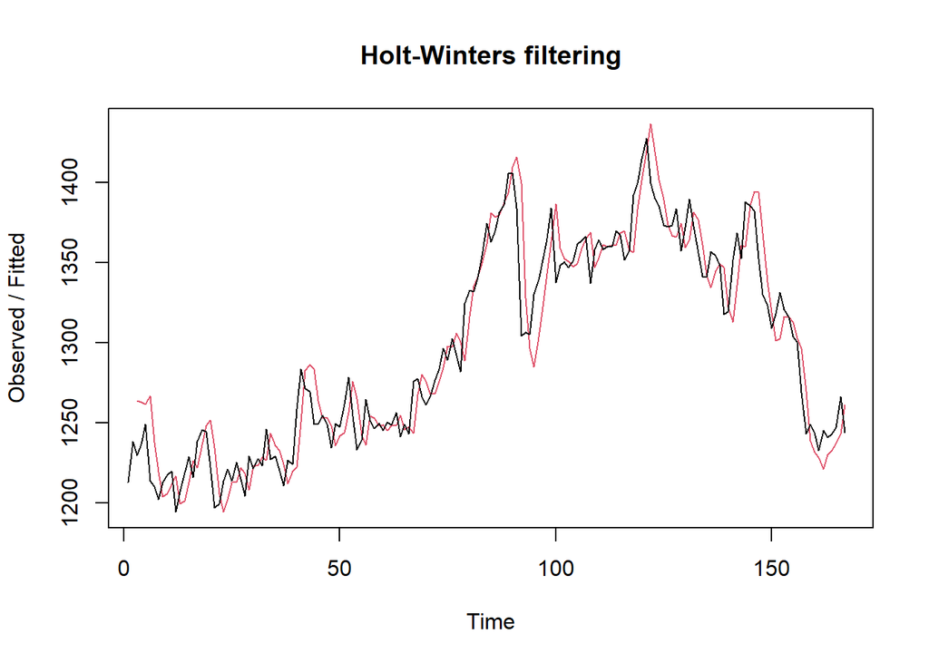

```r
des.2<- HoltWinters(train.ts, gamma = FALSE, beta = 0.3, alpha = 0.6)
plot(des.2)
```

```r
ramalandes2<- forecast(des.2, h=42)
ramalandes2
```

```
##     Point Forecast     Lo 80    Hi 80     Lo 95    Hi 95
## 168       1252.118 1226.4762 1277.759 1212.9025 1291.333
## 169       1253.178 1220.6586 1285.697 1203.4441 1302.911
## 170       1254.238 1213.4528 1295.023 1191.8625 1316.613
## 171       1255.298 1205.1195 1305.476 1178.5566 1332.039
## 172       1256.358 1195.8315 1316.885 1163.7907 1348.925
## 173       1257.418 1185.7049 1329.131 1147.7422 1367.094
## 174       1258.478 1174.8215 1342.135 1130.5363 1386.420
## 175       1259.538 1163.2417 1355.835 1112.2653 1406.811
## 176       1260.598 1151.0119 1370.185 1093.0003 1428.197
## 177       1261.659 1138.1697 1385.147 1072.7986 1450.519
## 178       1262.719 1124.7456 1400.692 1051.7070 1473.730
## 179       1263.779 1110.7657 1416.792 1029.7655 1497.792
## 180       1264.839 1096.2525 1433.425 1007.0082 1522.670
## 181       1265.899 1081.2254 1450.573  983.4650 1548.333
```

[output cut: 28 more lines]

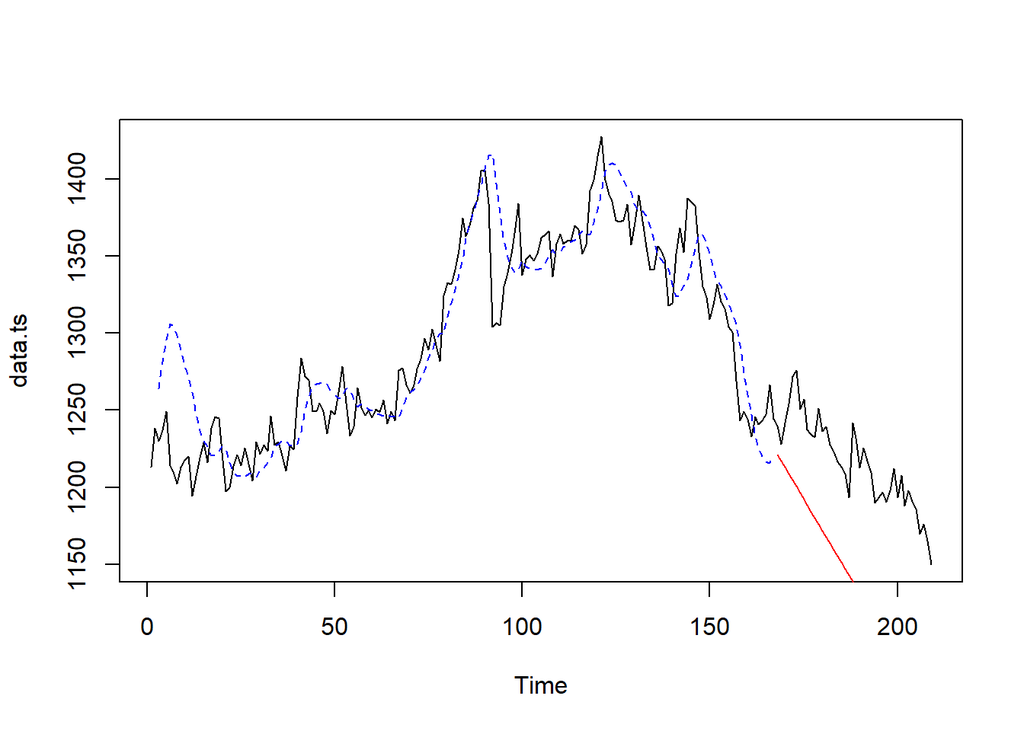

```r
plot(data.ts)
lines(des.1$fitted[,1], lty=2, col="blue")
lines(ramalandes1$mean, col="red")
```

```r
des.opt<- HoltWinters(train.ts, gamma = FALSE)
des.opt
```

```
## Holt-Winters exponential smoothing with trend and without seasonal component.
##
## Call:
## HoltWinters(x = train.ts, gamma = FALSE)
##
## Smoothing parameters:
##  alpha: 1
##  beta : 0.09512151
##  gamma: FALSE
##
## Coefficients:
##          [,1]
## a 1244.240000
## b   -3.411316
```

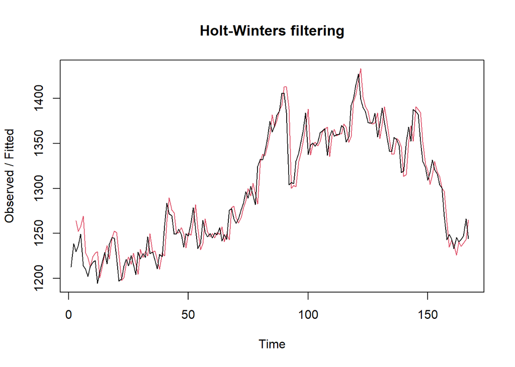

```r
plot(des.opt)
```

```r
ramalandesopt<- forecast(des.opt, h=42)
ramalandesopt
```

```
##     Point Forecast     Lo 80    Hi 80     Lo 95    Hi 95
## 168       1240.829 1218.1834 1263.474 1206.1957 1275.462
## 169       1237.417 1203.8344 1271.000 1186.0566 1288.778
## 170       1234.006 1190.9444 1277.068 1168.1490 1299.863
## 171       1230.595 1178.6183 1282.571 1151.1037 1310.086
## 172       1227.183 1166.5301 1287.837 1134.4222 1319.945
## 173       1223.772 1154.5231 1293.021 1117.8649 1329.679
## 174       1220.361 1142.5108 1298.211 1101.2995 1339.422
## 175       1216.949 1130.4411 1303.458 1084.6463 1349.253
## 176       1213.538 1118.2810 1308.795 1067.8549 1359.221
## 177       1210.127 1106.0086 1314.245 1050.8918 1369.362
## 178       1206.716 1093.6094 1319.822 1033.7347 1379.696
## 179       1203.304 1081.0734 1325.535 1016.3683 1390.240
## 180       1199.893 1068.3937 1331.392  998.7823 1401.004
## 181       1196.482 1055.5658 1337.397  980.9695 1411.994
```

[output cut: 28 more lines]

### 5.4.1 Akurasi Data Latih

```r
ssedes.train1<-des.1$SSE
msedes.train1<-ssedes.train1/length(train.ts)
sisaandes1<-ramalandes1$residuals
head(sisaandes1)
```

```
## Time Series:
## Start = 1
## End = 6
## Frequency = 1
## [1]        NA        NA -34.13000 -44.61880 -45.34509 -92.14231
```

```r
mapedes.train1 <- sum(abs(sisaandes1[3:length(train.ts)]/train.ts[3:length(train.ts)])
                      *100)/length(train.ts)

akurasides.1 <- matrix(c(ssedes.train1,msedes.train1,mapedes.train1))
row.names(akurasides.1)<- c("SSE", "MSE", "MAPE")
colnames(akurasides.1) <- c("Akurasi lamda=0.2 dan gamma=0.2")
akurasides.1
```

```
##      Akurasi lamda=0.2 dan gamma=0.2
## SSE                     1.382836e+05
## MSE                     8.280454e+02
## MAPE                    1.596997e+00
```

```r
ssedes.train2<-des.2$SSE
msedes.train2<-ssedes.train2/length(train.ts)
sisaandes2<-ramalandes2$residuals
head(sisaandes2)
```

```
## Time Series:
## Start = 1
## End = 6
## Frequency = 1
## [1]        NA        NA -34.13000 -26.18860 -12.41809 -52.70463
```

```r
mapedes.train2 <- sum(abs(sisaandes2[3:length(train.ts)]/train.ts[3:length(train.ts)])
                      *100)/length(train.ts)

akurasides.2 <- matrix(c(ssedes.train2,msedes.train2,mapedes.train2))
row.names(akurasides.2)<- c("SSE", "MSE", "MAPE")
colnames(akurasides.2) <- c("Akurasi lamda=0.6 dan gamma=0.3")
akurasides.2
```

```
##      Akurasi lamda=0.6 dan gamma=0.3
## SSE                     65764.156629
## MSE                       393.797345
## MAPE                        1.157037
```

```r
ssedes.train3<-des.opt$SSE
msedes.train3<-ssedes.train3/length(train.ts)
sisaandes3<-ramalandesopt$residuals
head(sisaandes3)
```

```
## Time Series:
## Start = 1
## End = 6
## Frequency = 1
## [1]         NA         NA -34.130000 -15.433503  -8.085445 -55.346345
```

```r
mapedes.train3 <- sum(abs(sisaandes3[3:length(train.ts)]/train.ts[3:length(train.ts)])
                      *100)/length(train.ts)

akurasides.opt <- matrix(c(ssedes.train3,msedes.train3,mapedes.train3))
row.names(akurasides.opt)<- c("SSE", "MSE", "MAPE")
colnames(akurasides.opt) <- c("Akurasi DES optimum")
akurasides.opt
```

```
##      Akurasi DES optimum
## SSE          51765.86249
## MSE            309.97522
## MAPE             1.00958
```

### 5.4.2 Akurasi Data Uji

```r
n_test <- length(testing$`Harga Rp/g`)

des1 <- HoltWinters(train.ts, gamma = FALSE, beta = 0.2, alpha = 0.2)
ramalandes1 <- forecast(des1, h = n_test)

des2 <- HoltWinters(train.ts, gamma = FALSE, beta = 0.3, alpha = 0.6)
ramalandes2 <- forecast(des2, h = n_test)

desopt <- HoltWinters(train.ts, gamma = FALSE, alpha = NULL, beta = NULL)
ramalandesopt <- forecast(desopt, h = n_test)

selisihdes1 <- ramalandes1$mean - testing$`Harga Rp/g`
selisihdes1
```

```
## Time Series:
## Start = 168
## End = 209
## Frequency = 1
##  [1]  -18.76691  -10.94064  -28.92437  -45.20810  -67.40183  -75.01556
##  [7]  -54.21929  -64.58302  -49.24676  -50.38049  -52.18422  -75.33795
## [13]  -64.75168  -71.70541  -63.75914  -63.78287  -61.12660  -61.70033
## [19]  -61.46406  -50.33779 -102.67152  -97.10525  -81.76898  -99.03271
## [25]  -94.59644  -91.56017  -75.83390  -83.20763  -90.72136  -88.41509
## [31] -100.01882 -118.28255 -103.69628 -122.48001 -106.81374 -120.82747
## [37] -117.88120 -117.24493 -105.00866 -115.51239 -108.45612  -97.32985
```

```r
SSEtestingdes1 <- sum(selisihdes1^2)
MSEtestingdes1 <- SSEtestingdes1 / length(testing$`Harga Rp/g`)
MAPEtestingdes1 <- sum(abs(selisihdes1 / testing$`Harga Rp/g`) * 100) / length(testing$`Harga Rp/g`)

selisihdes2 <- ramalandes2$mean - testing$`Harga Rp/g`
selisihdes2
```

```
## Time Series:
## Start = 168
## End = 209
## Frequency = 1
##  [1]  12.097525  25.097642  12.287759   1.177876 -15.842007 -18.281890
##  [7]   7.688228   2.498345  23.008462  27.048579  30.418696  12.438813
## [13]  28.198930  26.419047  39.539164  44.689281  52.519399  57.119516
## [19]  62.529633  78.829750  31.669867  42.409984  62.920101  50.830218
## [25]  60.440335  68.650453  89.550570  87.350687  85.010804  92.490921
## [31]  86.061038  72.971155  92.731272  79.121389  99.961507  91.121624
## [37]  99.241741 105.051858 122.461975 117.132092 129.362209 145.662326
```

```r
SSEtestingdes2 <- sum(selisihdes2^2)
MSEtestingdes2 <- SSEtestingdes2 / length(testing$`Harga Rp/g`)
MAPEtestingdes2 <- sum(abs(selisihdes2 / testing$`Harga Rp/g`) * 100) / length(testing$`Harga Rp/g`)

selisihdesopt <- ramalandesopt$mean - testing$`Harga Rp/g`
selisihdesopt
```

```
## Time Series:
## Start = 168
## End = 209
## Frequency = 1
##  [1]   0.8086838   9.3373675  -7.9439487 -23.5252650 -45.0165812 -51.9278975
##  [7] -30.4292137 -40.0905299 -24.0518462 -24.4831624 -25.5844787 -48.0357949
## [13] -36.7471111 -42.9984274 -34.3497436 -33.6710599 -30.3123761 -30.1836924
## [19] -29.2450086 -17.4163248 -69.0476411 -62.7789573 -46.7402736 -63.3015898
## [25] -58.1629061 -54.4242223 -37.9955385 -44.6668548 -51.4781710 -48.4694873
## [31] -59.3708035 -76.9321197 -61.6434360 -79.7247522 -63.3560685 -76.6673847
## [37] -73.0187010 -71.6800172 -58.7413334 -68.5426497 -60.7839659 -48.9552822
```

```r
SSEtestingdesopt <- sum(selisihdesopt^2)
MSEtestingdesopt <- SSEtestingdesopt / length(testing$`Harga Rp/g`)
MAPEtestingdesopt <- sum(abs(selisihdesopt / testing$`Harga Rp/g`) * 100) / length(testing$`Harga Rp/g`)

akurasitestingdes <- matrix(
  c(SSEtestingdes1, MSEtestingdes1, MAPEtestingdes1,
    SSEtestingdes2, MSEtestingdes2, MAPEtestingdes2,
    SSEtestingdesopt, MSEtestingdesopt, MAPEtestingdesopt),
  nrow = 3, ncol = 3
)

row.names(akurasitestingdes) <- c("SSE", "MSE", "MAPE")
colnames(akurasitestingdes) <- c("des ske1", "des ske2", "des opt")
akurasitestingdes
```

```
##          des ske1     des ske2      des opt
## SSE  2.968423e+05 2.076996e+05 1.044863e+05
## MSE  7.067674e+03 4.945230e+03 2.487770e+03
## MAPE 6.551785e+00 4.947869e+00 3.781452e+00
```

## 5.5 Winter Aditif

```r
train.ts.winter <- ts(training$`Harga Rp/g`, frequency = 7)
test.ts.winter  <- ts(testing$`Harga Rp/g`, frequency = 7)

winter1 <- HoltWinters(train.ts.winter,alpha=0.2,beta=0.1,gamma=0.1,seasonal = "additive")
winter1$fitted
```

```
## Time Series:
## Start = c(2, 1)
## End = c(24, 6)
## Frequency = 7
##               xhat    level        trend       season
##  2.000000 1210.753 1230.853 -2.835493197 -17.26510204
##  2.142857 1224.839 1226.333 -3.003950680   1.50918367
##  2.285714 1224.774 1221.016 -3.235323367   6.99346939
##  2.428571 1220.941 1216.384 -3.375000764   7.93204082
##  2.571429 1231.513 1212.836 -3.392214095  22.06918367
##  2.714286 1188.249 1202.050 -4.131683334  -9.66938776
##  2.857143 1186.404 1201.724 -3.751053631 -11.56938776
##  3.000000 1183.525 1204.556 -3.092728795 -17.93893197
##  3.142857 1208.994 1210.591 -2.180023467   0.58369293
##  3.285714 1214.237 1209.840 -2.037111233   6.43475980
##  3.428571 1218.938 1212.629 -1.554460558   7.86318749
##  3.571429 1234.506 1216.415 -1.020419361  19.11130671
##  3.714286 1208.444 1217.410 -0.818940401  -8.14686894
##  3.857143 1209.954 1219.426 -0.535414911  -8.93608841
##  4.000000 1201.270 1216.348 -0.789701832 -14.28811066
##  4.142857 1215.578 1215.244 -0.821096887   1.15534186
##  4.285714 1221.571 1214.063 -0.857060044   8.36536250
##  4.428571 1222.262 1213.128 -0.864889781   9.99935228
##  4.571429 1229.517 1210.628 -1.028335571  19.91722256
##  4.714286 1200.660 1208.783 -1.110082897  -7.01276698
##  4.857143 1199.832 1210.603 -0.817079309  -9.95323610
##  5.000000 1195.593 1210.729 -0.722725470 -14.41369088
##  5.142857 1217.755 1216.788 -0.044578794   1.01148924
##  5.285714 1225.898 1217.530  0.034126520   8.33404355
##  5.428571 1227.327 1217.913  0.068957155   9.34556912
##  5.571429 1236.823 1217.238 -0.005387991  19.59023325
##  5.714286 1213.461 1219.118  0.183150369  -5.84075263
##  5.857143 1213.000 1222.111  0.464137767  -9.57582074
##  6.000000 1214.927 1225.837  0.790346292 -11.70110417
##  6.142857 1229.988 1227.758  0.903411855   1.32631049
##  6.285714 1233.830 1224.836  0.520847776   8.47336609
##  6.428571 1233.408 1223.977  0.382838444   9.04818854
##  6.571429 1243.130 1222.580  0.204877761  20.34438669
##  6.714286 1221.725 1225.923  0.518687697  -4.71680304
##  6.857143 1232.353 1238.863  1.760785686  -8.27098664
```

[output cut: 110 more lines]

```
## 22.714286 1329.069 1328.913 -2.332052071   2.48844084
## 22.857143 1321.393 1324.867 -2.503437018  -0.97032173
## 23.000000 1312.791 1321.293 -2.610500985  -5.89185368
## 23.142857 1312.799 1316.904 -2.788311499  -1.31697780
## 23.285714 1304.580 1311.672 -3.032691198  -4.05959289
## 23.428571 1300.555 1301.489 -3.747688832   2.81324457
## 23.571429 1290.320 1286.265 -4.895389911   8.95082520
## 23.714286 1269.208 1273.125 -5.719794589   1.80290105
## 23.857143 1254.807 1262.424 -6.217963956  -1.39857760
## 24.000000 1238.614 1251.868 -6.651710598  -6.60309574
## 24.142857 1237.803 1246.610 -6.512383337  -2.29449659
## 24.285714 1227.360 1240.729 -6.449245844  -6.91958343
## 24.428571 1229.573 1237.480 -6.129249197  -1.77755975
## 24.571429 1234.728 1234.854 -5.778907368   5.65320649
## 24.714286 1230.098 1235.431 -5.143271082  -0.18977642
```

```r
xhat1 <- winter1$fitted[,2]

winter1.opt<- HoltWinters(train.ts.winter, alpha= NULL,  beta = NULL, gamma = NULL, seasonal = "additive")
winter1.opt
```

```
## Holt-Winters exponential smoothing with trend and additive seasonal component.
##
## Call:
## HoltWinters(x = train.ts.winter, alpha = NULL, beta = NULL, gamma = NULL,     seasonal = "additive")
##
## Smoothing parameters:
##  alpha: 0.8809111
##  beta : 0.008779044
##  gamma: 1
##
## Coefficients:
##            [,1]
## a  1235.6976384
## b    -1.1620079
## s1    7.0942554
## s2    4.1211299
## s3   -0.2839813
## s4   -9.0354026
## s5    1.0305554
## s6   14.3010420
## s7    8.5423616
```

```r
winter1.opt$fitted
```

```
## Time Series:
## Start = c(2, 1)
## End = c(24, 6)
## Frequency = 7
##               xhat    level       trend       season
##  2.000000 1210.753 1230.853 -2.83549320 -17.26510204
##  2.142857 1219.207 1220.598 -2.90063198   1.50918367
##  2.285714 1216.515 1212.468 -2.94654398   6.99346939
##  2.428571 1215.640 1210.645 -2.93668168   7.93204082
##  2.571429 1230.786 1211.619 -2.90234484  22.06918367
##  2.714286 1163.935 1176.787 -3.18265572  -9.66938776
##  2.857143 1197.371 1211.788 -2.84744679 -11.56938776
##  3.000000 1207.330 1228.275 -2.67770045 -18.26817261
##  3.142857 1243.122 1244.828 -2.50887375   0.80218588
##  3.285714 1222.979 1218.551 -2.71753848   7.14533872
##  3.428571 1235.254 1229.392 -2.59851005   8.46079297
##  3.571429 1251.177 1235.942 -2.51818953  17.75268299
##  3.714286 1220.536 1227.613 -2.56920663  -4.50751321
##  3.857143 1215.371 1226.879 -2.55309150  -8.95546786
##  4.000000 1189.993 1208.355 -2.69330707 -15.66841430
##  4.142857 1209.183 1214.212 -2.61823683  -2.41103746
##  4.285714 1222.039 1215.644 -2.58268671   8.97825486
##  4.428571 1219.412 1212.304 -2.58933115   9.69764664
##  4.571429 1219.363 1205.026 -2.63049207  16.96707195
##  4.714286 1200.897 1207.740 -2.58357079  -4.25935680
##  4.857143 1204.266 1217.853 -2.47211059 -11.11464406
##  5.000000 1198.649 1215.631 -2.46991603 -14.51240942
##  5.142857 1236.243 1240.338 -2.23132437  -1.86360201
##  5.285714 1231.819 1225.287 -2.34387405   8.87593726
##  5.428571 1225.949 1219.262 -2.37619116   9.06381063
##  5.571429 1230.120 1214.825 -2.39428252  17.68961161
##  5.714286 1221.827 1226.639 -2.26954106  -2.54298378
##  5.857143 1216.070 1229.376 -2.22559105 -11.08085010
##  6.000000 1225.853 1238.814 -2.12319687 -10.83834205
##  6.142857 1226.286 1232.046 -2.16397240  -3.59675186
##  6.285714 1222.389 1216.294 -2.28326654   8.37828689
##  6.428571 1224.548 1218.011 -2.24814676   8.78522215
##  6.571429 1233.091 1215.729 -2.24844047  19.61050237
##  6.714286 1232.230 1236.146 -2.04946658  -1.86619848
##  6.857143 1268.397 1279.551 -1.65041376  -9.50408455
```

[output cut: 110 more lines]

```
## 22.714286 1328.786 1317.617 -0.57087725  11.74032189
## 22.857143 1317.209 1309.747 -0.63496103   8.09702091
## 23.000000 1310.026 1308.082 -0.64399818   2.58765613
## 23.142857 1300.987 1302.042 -0.69137240  -0.36316724
## 23.285714 1292.406 1300.992 -0.69452242  -7.89089711
## 23.428571 1285.431 1279.529 -0.87685075   6.77884358
## 23.571429 1254.143 1241.424 -1.20367522  13.92298957
## 23.714286 1245.288 1235.778 -1.24267735  10.75349731
## 23.857143 1240.372 1233.664 -1.25032138   7.95785812
## 24.000000 1226.577 1226.026 -1.30640320   1.85814154
## 24.142857 1239.888 1241.459 -1.15944614  -0.41167438
## 24.285714 1229.394 1241.244 -1.15115383 -10.69856669
## 24.428571 1253.098 1252.395 -1.04314898   1.74608125
## 24.571429 1258.292 1246.059 -1.08961479  13.32239664
## 24.714286 1261.819 1252.209 -1.02606216  10.63578709
```

```r
xhat1.opt <- winter1.opt$fitted[,2]
```

```r
forecast1 <- predict(winter1, n.ahead = 42)
forecast1.opt <- predict(winter1.opt, n.ahead = 42)
forecast1.opt
```

```
## Time Series:
## Start = c(24, 7)
## End = c(30, 6)
## Frequency = 7
##            fit
##  [1,] 1241.630
##  [2,] 1237.495
##  [3,] 1231.928
##  [4,] 1222.014
##  [5,] 1230.918
##  [6,] 1243.027
##  [7,] 1236.106
##  [8,] 1233.496
##  [9,] 1229.361
## [10,] 1223.794
```

[output cut: 32 more lines]

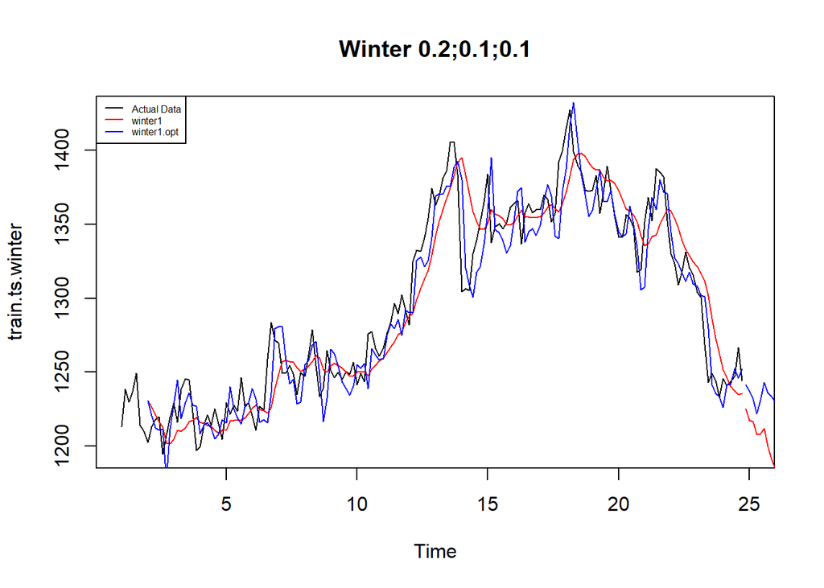

```r
plot(train.ts.winter,main="Winter 0.2;0.1;0.1",type="l",col="black",
     xlim=c(1,25),pch=12)
lines(xhat1,type="l",col="red")
lines(xhat1.opt,type="l",col="blue")
lines(forecast1,type="l",col="red")
lines(forecast1.opt,type="l",col="blue")
legend("topleft",c("Actual Data",expression(paste(winter1)),
                   expression(paste(winter1.opt))),cex=0.5,
       col=c("black","red","blue"),lty=1)
```

```r
alpha_winter <- winter1.opt$alpha
beta_winter  <- winter1.opt$beta
gamma_winter <- winter1.opt$gamma

ada_tren <- ifelse(beta_winter > 0.01, TRUE, FALSE)
ada_musiman <- ifelse(gamma_winter > 0.01, TRUE, FALSE)

ada_tren
```

```
##  beta
## FALSE
```

```r
ada_musiman
```

```
## gamma
##  TRUE
```

### 5.5.1 Akurasi Data Latih

```r
SSE1 <- winter1$SSE
MSE1 <- winter1$SSE / length(train.ts.winter)
RMSE1 <- sqrt(MSE1)


fitted1 <- as.numeric(winter1$fitted[, 1])
error_train1 <- as.numeric(train.ts.winter) - fitted1
```

```r
MAPE1 <- mean(abs((error_train1 / as.numeric(train.ts.winter)) * 100), na.rm = TRUE)

akurasi1 <- matrix(c(SSE1, MSE1, RMSE1, MAPE1), nrow = 4)
row.names(akurasi1) <- c("SSE", "MSE", "RMSE", "MAPE")
colnames(akurasi1) <- c("Akurasi Winter Aditif Manual")
akurasi1
```

```
##      Akurasi Winter Aditif Manual
## SSE                   93812.94260
## MSE                     561.75415
## RMSE                     23.70135
## MAPE                      1.58083
```

```r
SSE1.opt <- winter1.opt$SSE
MSE1.opt <- winter1.opt$SSE / length(train.ts.winter)
RMSE1.opt <- sqrt(MSE1.opt)

fitted1.opt <- as.numeric(winter1.opt$fitted[, 1])
error_train1.opt <- as.numeric(train.ts.winter) - fitted1.opt
```

```r
MAPE1.opt <- mean(abs((error_train1.opt / as.numeric(train.ts.winter)) * 100), na.rm = TRUE)

akurasi1.opt <- matrix(c(SSE1.opt, MSE1.opt, RMSE1.opt, MAPE1.opt), nrow = 4)
row.names(akurasi1.opt) <- c("SSE", "MSE", "RMSE", "MAPE")
colnames(akurasi1.opt) <- c("Akurasi Winter Aditif Optimum")
akurasi1.opt
```

```
##      Akurasi Winter Aditif Optimum
## SSE                   56847.358574
## MSE                     340.403345
## RMSE                     18.450023
## MAPE                      2.153792
```

### 5.5.2 Akurasi Data Uji

```r
forecast1_vec <- as.numeric(forecast1[, 1])
aktual_vec <- as.numeric(testing$`Harga Rp/g`)

n <- min(length(forecast1_vec), length(aktual_vec))
forecast1_vec <- forecast1_vec[1:n]
aktual_vec <- aktual_vec[1:n]

selisih1 <- forecast1_vec - aktual_vec

valid <- is.finite(selisih1) & is.finite(aktual_vec) & aktual_vec != 0
selisih_clean <- selisih1[valid]
aktual_clean <- aktual_vec[valid]

SSE1 <- sum(selisih_clean^2)
MSE1 <- SSE1 / length(aktual_clean)
MAPE1 <- mean(abs(selisih_clean / aktual_clean) * 100)

forecast1.opt_vec <- as.numeric(forecast1.opt[, 1])
forecast1.opt_vec <- forecast1.opt_vec[1:n]
selisih1.opt <- forecast1.opt_vec - aktual_vec

valid_opt <- is.finite(selisih1.opt) & is.finite(aktual_vec) & aktual_vec != 0
selisih_opt_clean <- selisih1.opt[valid_opt]
aktual_opt_clean <- aktual_vec[valid_opt]

SSE1.opt <- sum(selisih_opt_clean^2)
MSE1.opt <- SSE1.opt / length(aktual_opt_clean)
MAPE1.opt <- mean(abs(selisih_opt_clean / aktual_opt_clean) * 100)

akurasi_testing <- data.frame(
  Model = c("Winter Additive Manual", "Winter Additive Optimum"),
  SSE   = c(SSE1, SSE1.opt),
  MSE   = c(MSE1, MSE1.opt),
  MAPE  = c(MAPE1, MAPE1.opt)
)

akurasi_testing
```

```
##                     Model       SSE       MSE     MAPE
## 1  Winter Additive Manual 384930.10 9165.0023 7.344979
## 2 Winter Additive Optimum  14998.31  357.1025 1.207651
```

## 5.6 Winter Multiplikatif

```r
winter2 <- HoltWinters(train.ts.winter,alpha=0.2,beta=0.1,gamma=0.3,seasonal = "multiplicative")
winter2$fitted
```

```
## Time Series:
## Start = c(2, 1)
## End = c(24, 6)
## Frequency = 7
##               xhat    level       trend    season
##  2.000000 1210.637 1230.853 -2.83549320 0.9858466
##  2.142857 1224.865 1226.333 -3.00402463 1.0012560
##  2.285714 1224.825 1221.013 -3.23563618 1.0057874
##  2.428571 1220.890 1216.378 -3.37552070 1.0065023
##  2.571429 1231.193 1212.842 -3.39161155 1.0179774
##  2.714286 1188.669 1202.249 -4.11172134 0.9920974
##  2.857143 1186.810 1201.889 -3.73653158 0.9905330
##  3.000000 1182.676 1204.717 -3.08010874 0.9842208
##  3.142857 1207.710 1211.083 -2.13551945 0.9989769
##  3.285714 1213.985 1210.635 -1.96674939 1.0043995
##  3.428571 1219.729 1213.524 -1.48119487 1.0063420
##  3.571429 1229.191 1217.192 -0.96624339 1.0106606
##  3.714286 1213.508 1219.271 -0.66171511 0.9958138
##  3.857143 1216.312 1220.439 -0.47870528 0.9970096
##  4.000000 1207.292 1216.135 -0.86129692 0.9934326
##  4.142857 1213.517 1213.745 -1.01414302 1.0006480
##  4.285714 1222.950 1212.783 -1.00887937 1.0092220
##  4.428571 1224.240 1211.424 -1.04394615 1.0114510
##  4.571429 1223.653 1208.373 -1.24464702 1.0136897
##  4.714286 1203.381 1207.479 -1.20959540 0.9976057
##  4.857143 1199.533 1208.661 -0.97044258 0.9932457
##  5.000000 1198.085 1208.700 -0.86942346 0.9919313
##  5.142857 1214.779 1214.165 -0.23602114 1.0007001
##  5.285714 1225.993 1215.310 -0.09789689 1.0088714
##  5.428571 1226.942 1215.539 -0.06524761 1.0094351
##  5.571429 1231.740 1214.814 -0.13125860 1.0140428
##  5.714286 1217.668 1217.544  0.15492738 0.9999744
##  5.857143 1212.994 1219.668  0.35177523 0.9942419
##  6.000000 1221.706 1223.301  0.67998037 0.9981409
##  6.142857 1226.941 1223.756  0.65742123 1.0020649
##  6.285714 1232.774 1221.203  0.33645417 1.0091966
##  6.428571 1231.315 1220.382  0.22063987 1.0087769
##  6.571429 1239.949 1219.253  0.08571450 1.0169030
##  6.714286 1225.845 1223.050  0.45685342 1.0019111
##  6.857143 1233.534 1235.082  1.61433417 0.9974429
```

[output cut: 110 more lines]

```
## 22.714286 1327.295 1325.242 -2.40455356 1.0033695
## 22.857143 1316.070 1321.483 -2.53999445 0.9978215
## 23.000000 1313.553 1318.937 -2.54059186 0.9978396
## 23.142857 1313.753 1314.462 -2.73406340 1.0015437
## 23.285714 1299.901 1309.097 -2.99711014 0.9952535
## 23.428571 1301.468 1299.856 -3.62148934 1.0040371
## 23.571429 1289.876 1284.622 -4.78275952 1.0078420
## 23.714286 1268.860 1271.748 -5.59193385 1.0021355
## 23.857143 1252.431 1261.254 -6.08207988 0.9978161
## 24.000000 1239.949 1251.302 -6.46914603 0.9960772
## 24.142857 1238.527 1245.963 -6.35608718 0.9991287
## 24.285714 1220.852 1240.094 -6.30738175 0.9895167
## 24.428571 1224.035 1238.336 -5.85246196 0.9931455
## 24.571429 1231.919 1237.126 -5.38818644 1.0001469
## 24.714286 1230.827 1238.655 -4.69646558 0.9974621
```

```r
xhat2 <- winter2$fitted[,2]

winter2.opt<- HoltWinters(train.ts.winter, alpha= NULL,  beta = NULL, gamma = NULL, seasonal = "multiplicative")
winter2.opt$fitted
```

```
## Time Series:
## Start = c(2, 1)
## End = c(24, 6)
## Frequency = 7
##               xhat    level       trend    season
##  2.000000 1210.637 1230.853 -2.83549320 0.9858466
##  2.142857 1219.301 1220.669 -2.89749934 1.0012560
##  2.285714 1216.577 1212.518 -2.94182307 1.0057874
##  2.428571 1215.548 1210.628 -2.93294846 1.0065023
##  2.571429 1230.452 1211.622 -2.89981715 1.0179774
##  2.714286 1165.513 1177.956 -3.15940561 0.9920974
##  2.857143 1197.220 1211.512 -2.84961844 0.9905330
##  3.000000 1207.024 1228.120 -2.68544557 0.9849762
##  3.142857 1243.284 1245.034 -2.52007622 1.0006198
##  3.285714 1223.331 1218.856 -2.71969064 1.0059156
##  3.428571 1235.128 1229.175 -2.60967507 1.0069806
##  3.571429 1250.498 1235.670 -2.53285792 1.0140784
##  3.714286 1221.191 1228.048 -2.57579679 0.9965065
##  3.857143 1215.386 1226.723 -2.56524454 0.9928344
##  4.000000 1190.148 1208.218 -2.69973123 0.9872500
##  4.142857 1208.628 1213.956 -2.62853843 0.9977716
##  4.285714 1222.315 1215.830 -2.59054660 1.0074804
##  4.428571 1219.418 1212.257 -2.59883990 1.0080686
##  4.571429 1218.598 1205.048 -2.63773526 1.0134621
##  4.714286 1201.669 1208.290 -2.58812742 0.9966555
##  4.857143 1204.109 1217.638 -2.48741824 0.9909136
##  5.000000 1198.809 1215.538 -2.48414392 0.9882563
##  5.142857 1235.795 1240.139 -2.25562075 0.9983135
##  5.285714 1232.205 1225.561 -2.35958823 1.0073606
##  5.428571 1225.987 1219.249 -2.39293248 1.0075031
##  5.571429 1229.587 1214.799 -2.41029067 1.0141853
##  5.714286 1222.087 1226.718 -2.28939210 0.9980882
##  5.857143 1215.826 1229.166 -2.24941375 0.9909600
##  6.000000 1226.026 1238.784 -2.14928485 0.9914215
##  6.142857 1225.770 1231.844 -2.18970766 0.9968416
##  6.285714 1222.666 1216.610 -2.29977231 1.0068818
##  6.428571 1224.552 1218.003 -2.26861347 1.0072529
##  6.571429 1232.750 1215.698 -2.26891780 1.0159225
##  6.714286 1232.066 1235.809 -2.08008995 0.9986525
##  6.857143 1267.466 1278.933 -1.69867565 0.9923521
```

[output cut: 110 more lines]

```
## 22.714286 1329.190 1317.737 -0.60207700 1.0091524
## 22.857143 1317.984 1309.625 -0.66544109 1.0068944
## 23.000000 1310.515 1307.276 -0.67964889 1.0029992
## 23.142857 1300.550 1300.844 -0.72817902 1.0003333
## 23.285714 1291.551 1300.143 -0.72795525 0.9939481
## 23.428571 1284.734 1279.479 -0.89616288 1.0048107
## 23.571429 1254.310 1242.508 -1.20054253 1.0104747
## 23.714286 1245.833 1236.811 -1.23848426 1.0083038
## 23.857143 1241.264 1234.247 -1.24966830 1.0067042
## 24.000000 1227.510 1225.943 -1.30919322 1.0023489
## 24.142857 1239.596 1240.356 -1.17653797 1.0003363
## 24.285714 1228.888 1240.368 -1.16650197 0.9916770
## 24.428571 1251.536 1251.929 -1.05911724 1.0005325
## 24.571429 1258.282 1246.995 -1.09181459 1.0099360
## 24.714286 1262.173 1253.008 -1.03186578 1.0081450
```

```r
xhat2.opt <- winter2.opt$fitted[,2]
```

```r
forecast2 <- predict(winter2, n.ahead = 42)
forecast2.opt <- predict(winter2.opt, n.ahead = 42)
```

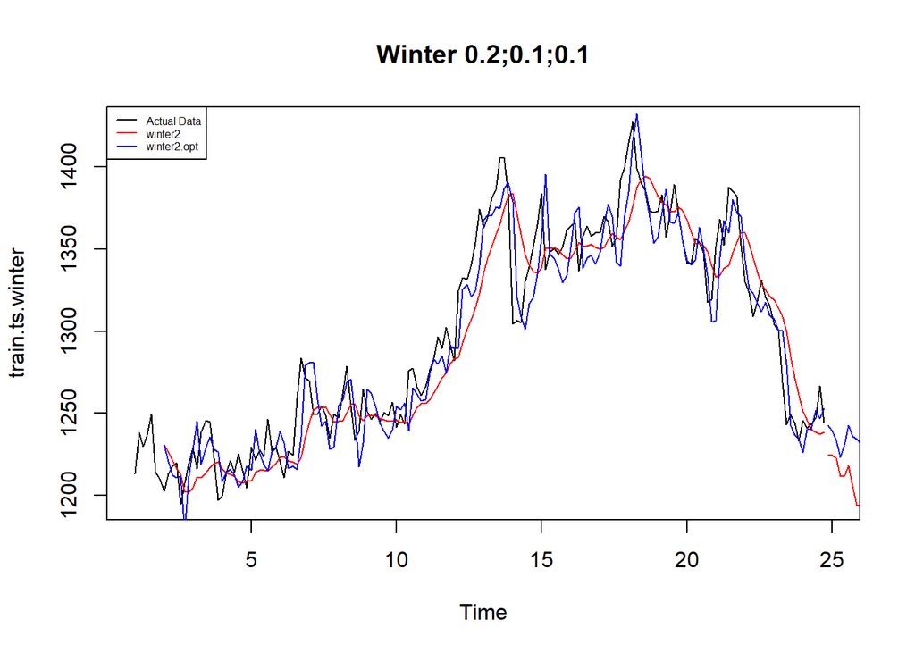

```r
plot(train.ts.winter,main="Winter 0.2;0.1;0.1",type="l",col="black",
     xlim=c(1,25),pch=12)
lines(xhat2,type="l",col="red")
lines(xhat2.opt,type="l",col="blue")
lines(forecast2,type="l",col="red")
lines(forecast2.opt,type="l",col="blue")
legend("topleft",c("Actual Data",expression(paste(winter2)),
                   expression(paste(winter2.opt))),cex=0.5,
       col=c("black","red","blue"),lty=1)
```

```r
alpha_mul <- winter2.opt$alpha
beta_mul  <- winter2.opt$beta
gamma_mul <- winter2.opt$gamma

ada_tren_mul <- ifelse(beta_mul > 0.01, TRUE, FALSE)
ada_musiman_mul <- ifelse(gamma_mul > 0.01, TRUE, FALSE)

ada_tren_mul
```

```
##  beta
## FALSE
```

```r
ada_musiman_mul
```

```
## gamma
##  TRUE
```

### 5.6.1 Akurasi Data Latih

```r
SSE2 <- winter2$SSE
MSE2 <- winter2$SSE / length(train.ts.winter)
RMSE2 <- sqrt(MSE2)

fitted2 <- as.numeric(winter2$fitted[, 1])
error_train2 <- as.numeric(train.ts.winter) - fitted2
```

```r
MAPE2 <- mean(abs((error_train2 / as.numeric(train.ts.winter)) * 100), na.rm = TRUE)

akurasi2 <- matrix(c(SSE2, MSE2, RMSE2, MAPE2), nrow = 4)
row.names(akurasi2) <- c("SSE", "MSE", "RMSE", "MAPE")
colnames(akurasi2) <- c("Akurasi Winter Multiplikatif Manual")
akurasi2
```

```
##      Akurasi Winter Multiplikatif Manual
## SSE                         96566.805552
## MSE                           578.244345
## RMSE                           24.046712
## MAPE                            1.546487
```

```r
SSE2.opt <- winter2.opt$SSE
MSE2.opt <- winter2.opt$SSE / length(train.ts.winter)
RMSE2.opt <- sqrt(MSE2.opt)

fitted2.opt <- as.numeric(winter2.opt$fitted[, 1])
error_train2.opt <- as.numeric(train.ts.winter) - fitted2.opt
```

```r
MAPE2.opt <- mean(abs((error_train2.opt / as.numeric(train.ts.winter)) * 100), na.rm = TRUE)

akurasi2.opt <- matrix(c(SSE2.opt, MSE2.opt, RMSE2.opt, MAPE2.opt), nrow = 4)
row.names(akurasi2.opt) <- c("SSE", "MSE", "RMSE", "MAPE")
colnames(akurasi2.opt) <- c("Akurasi Winter Multiplikatif Optimum")
akurasi2.opt
```

```
##      Akurasi Winter Multiplikatif Optimum
## SSE                           57600.92155
## MSE                             344.91570
## RMSE                             18.57191
## MAPE                              2.15088
```

### 5.6.2 Akurasi Data Uji

```r
forecast2_vec <- as.numeric(forecast2[, 1])
aktual_vec <- as.numeric(testing$`Harga Rp/g`)

n <- min(length(forecast2_vec), length(aktual_vec))
forecast2_vec <- forecast2_vec[1:n]
aktual_vec <- aktual_vec[1:n]

selisih2 <- forecast2_vec - aktual_vec

valid2 <- is.finite(selisih2) & is.finite(aktual_vec) & aktual_vec != 0
selisih2_clean <- selisih2[valid2]
aktual2_clean <- aktual_vec[valid2]

SSE2 <- sum(selisih2_clean^2)
MSE2 <- SSE2 / length(aktual2_clean)
MAPE2 <- mean(abs(selisih2_clean / aktual2_clean) * 100)

forecast2.opt_vec <- as.numeric(forecast2.opt[, 1])
forecast2.opt_vec <- forecast2.opt_vec[1:n]
selisih2.opt <- forecast2.opt_vec - aktual_vec

valid2.opt <- is.finite(selisih2.opt) & is.finite(aktual_vec) & aktual_vec != 0
selisih2.opt_clean <- selisih2.opt[valid2.opt]
aktual2.opt_clean <- aktual_vec[valid2.opt]

SSE2.opt <- sum(selisih2.opt_clean^2)
MSE2.opt <- SSE2.opt / length(aktual2.opt_clean)
MAPE2.opt <- mean(abs(selisih2.opt_clean / aktual2.opt_clean) * 100)

akurasi_testing2 <- data.frame(
  Model = c("Winter Multiplikatif Manual", "Winter Multiplikatif Optimum"),
  SSE   = c(SSE2, SSE2.opt),
  MSE   = c(MSE2, MSE2.opt),
  MAPE  = c(MAPE2, MAPE2.opt)
)

akurasi_testing2
```

```
##                          Model       SSE       MSE     MAPE
## 1  Winter Multiplikatif Manual 286944.57 6832.0135 6.329691
## 2 Winter Multiplikatif Optimum  14591.25  347.4107 1.194928
```

# 6 Perbandingan Akurasi Data Uji

```r
tabel_akurasi <- data.frame(
  Metode = c("SMA", "DMA", "SES", "DES Optimum", "Winter Add Optimum", "Winter Mul Optimum"),
  SSE = c(
    akurasi_test.sma[1],
    akurasi_test.dma[1],
    akurasi_test[1],
    akurasitestingdes[1, 3],
    akurasi_testing[2, 2],
    akurasi_testing2[2, 2]
  ),
  MSE = c(
    akurasi_test.sma[2],
    akurasi_test.dma[2],
    akurasi_test[2],
    akurasitestingdes[2, 3],
    akurasi_testing[2, 3],
    akurasi_testing2[2, 3]
  ),
  RMSE = c(
    sqrt(akurasi_test.sma[2]),
    sqrt(akurasi_test.dma[2]),
    akurasi_test[3],
    sqrt(akurasitestingdes[2, 3]),
    sqrt(akurasi_testing[2, 3]),
    sqrt(akurasi_testing2[2, 3])
  ),
  MAPE = c(
    akurasi_test.sma[3],
    akurasi_test.dma[3],
    akurasi_test[4],
    akurasitestingdes[3, 3],
    akurasi_testing[2, 4],
    akurasi_testing2[2, 4]
  )
)
tabel_akurasi
```

```
##               Metode       SSE        MSE      RMSE     MAPE
## 1                SMA  82822.70  1971.9690  44.40686 3.083589
## 2                DMA 523920.69 12474.3021 111.68842 7.929323
## 3                SES  67004.66  1595.3491  39.94182 2.722506
## 4        DES Optimum 104486.34  2487.7701  49.87755 3.781452
## 5 Winter Add Optimum  14998.31   357.1025  18.89716 1.207651
## 6 Winter Mul Optimum  14591.25   347.4107  18.63896 1.194928
```

# 7 Kesimpulan

Metode pemulusan terbaik adalah Metode Winter Multiplikatif. Berdasarkan hasil optimasi parameter pada model Holt-Winters Aditif dan Multiplikatif, kedua model secara konsisten menunjukkan bahwa data tidak memiliki tren yang signifikan (beta < 0.01), tetapi memiliki komponen musiman yang kuat (gamma > 0.01). Hal ini mengindikasikan bahwa metode yang memperhitungkan musiman, seperti Holt-Winters, lebih sesuai untuk data ini. Hal ini juga ditunjukkan oleh metriks SSE, MSE, RMSE, dan MAPE dari kedua metode Winter yang tidak jauh berbeda satu sama lain dan menjadi nilai error yang kecil jika dibandingkan dengan metode lainnya. Namun, metode Winter Multiplikatif tetap konsisten menunjukkan nilai error terkecil sehingga metode ini mempunyai kesalahan prediksi lebih kecil dan peramalan yang dihasilkan paling mendekati data aktual dibandingkan metode lain.

# Tugas Pertemuan 1

Praktikum

Nabila Nur Faizah

26 August 2026

# 1 Library/Packages

```r
library(forecast)
```

```r
library(graphics)
library(TTR)
library(TSA)
library(rio)
library(ggplot2)
library(dplyr)
library(stats)
```

# 2 Impor Data

```r
data<- import("https://raw.githubusercontent.com/nabilaanf/mpdw/refs/heads/main/Pertemuan%201/Gugus%20Data%20yang%20Dipakai_XAU_IDR%20Historical%20Data.xlsx")

data$Date<-as.Date(data$Date, format="%m/%d/%Y")
data<-data[order(data$Date),]
data
```

```
##           Date   Price Harga Rp/g
## 199 2024-04-15 377.307    1213.07
## 198 2024-04-16 385.232    1238.55
## 197 2024-04-17 382.543    1229.90
## 196 2024-04-18 384.656    1236.70
## 195 2024-04-19 388.601    1249.38
## 194 2024-04-22 377.606    1214.03
## 193 2024-04-23 376.478    1210.40
## 192 2024-04-24 373.967    1202.33
## 191 2024-04-25 377.368    1213.27
## 190 2024-04-26 378.774    1217.79
## 189 2024-04-29 379.488    1220.08
## 188 2024-04-30 371.545    1194.54
## 179 2024-05-13 375.507    1207.28
## 178 2024-05-14 379.250    1219.32
```

[output cut: 195 more lines]

# 3 Eksplorasi Data

```r
View(data)
str(data)
```

```
## 'data.frame':    209 obs. of  3 variables:
##  $ Date      : Date, format: "2024-04-15" "2024-04-16" ...
##  $ Price     : num  377 385 383 385 389 ...
##  $ Harga Rp/g: num  1213 1239 1230 1237 1249 ...
```

```r
dim(data)
```

```
## [1] 209   3
```

```r
data.ts<-ts(data$`Harga Rp/g`)
summary(data.ts)
```

```
##    Min. 1st Qu.  Median    Mean 3rd Qu.    Max.
##    1150    1228    1254    1280    1348    1427
```

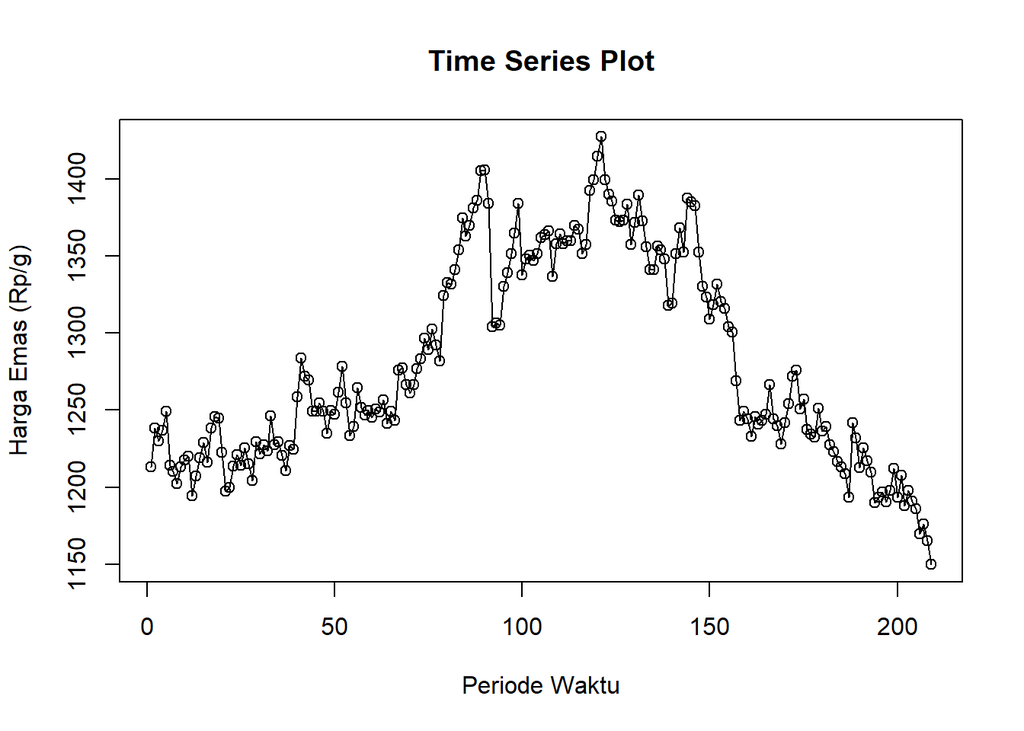

```r
ts.plot(data.ts, xlab="Periode Waktu", ylab="Harga Emas (Rp/g)",
        main = "Time Series Plot")
points(data.ts)
```

# 4 Pembagian Data

```r
n <- nrow(data)
n_train <- floor(0.8 * n)

training <- data[1:n_train, ]
testing  <- data[(n_train + 1):n, ]

train.ts <- ts(training$`Harga Rp/g`)
test.ts  <- ts(testing$`Harga Rp/g`)

cat("Training :", length(train.ts), "data\n")
```

```
## Training : 167 data
```

```r
cat("Testing  :", length(test.ts), "data\n")
```

```
## Testing  : 42 data
```

## 4.1 Eksplorasi Data Latih dan Data Uji

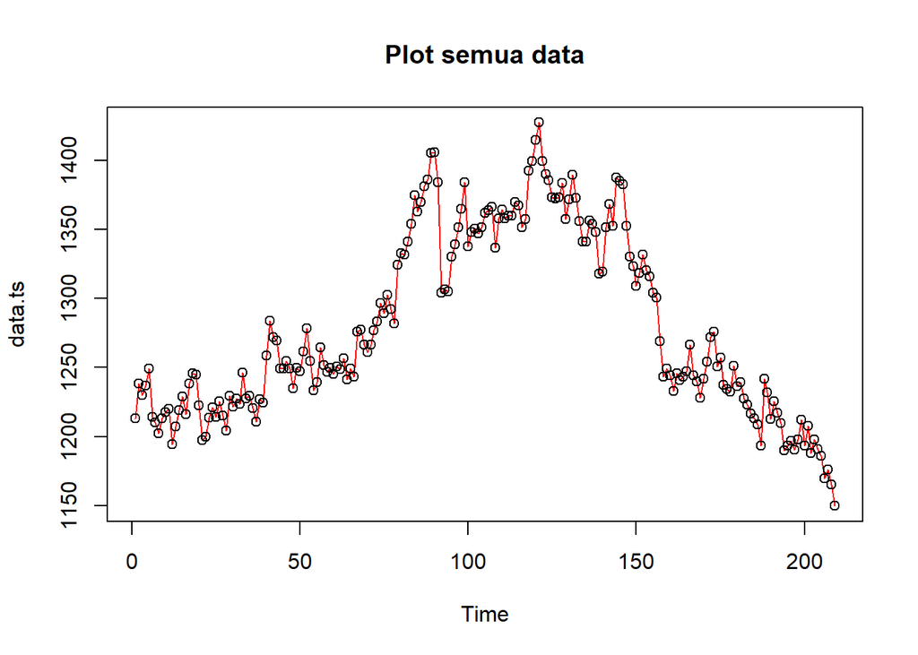

```r
plot(data.ts, col="red",main="Plot semua data")
points(data.ts)
```

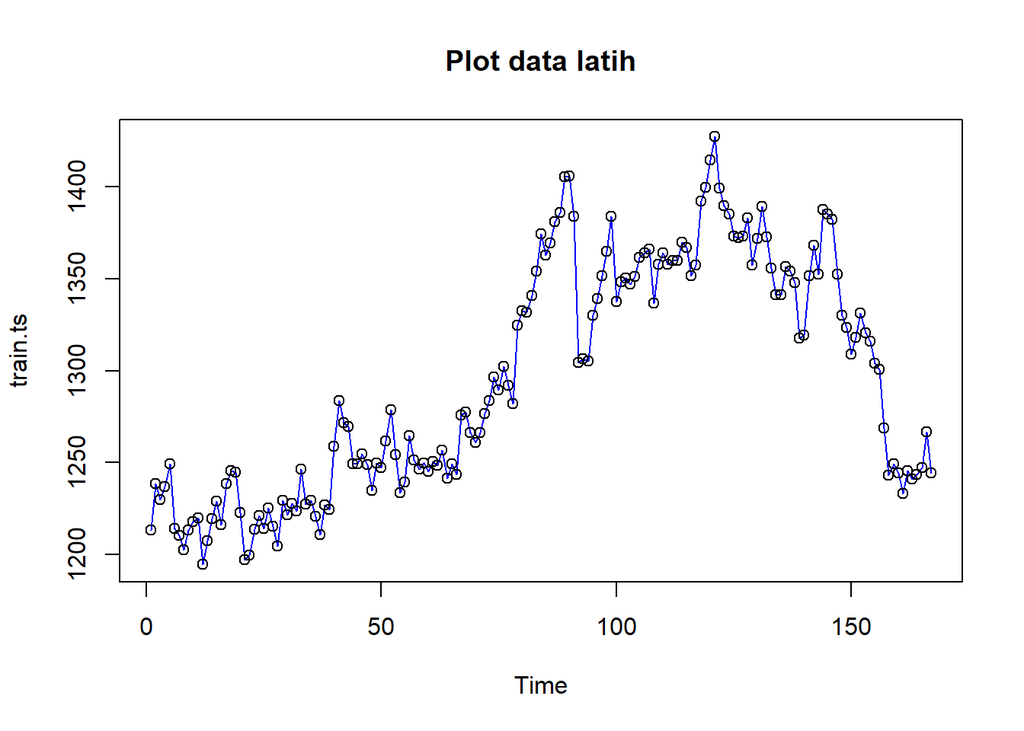

```r
plot(train.ts, col="blue",main="Plot data latih")
points(train.ts)
```

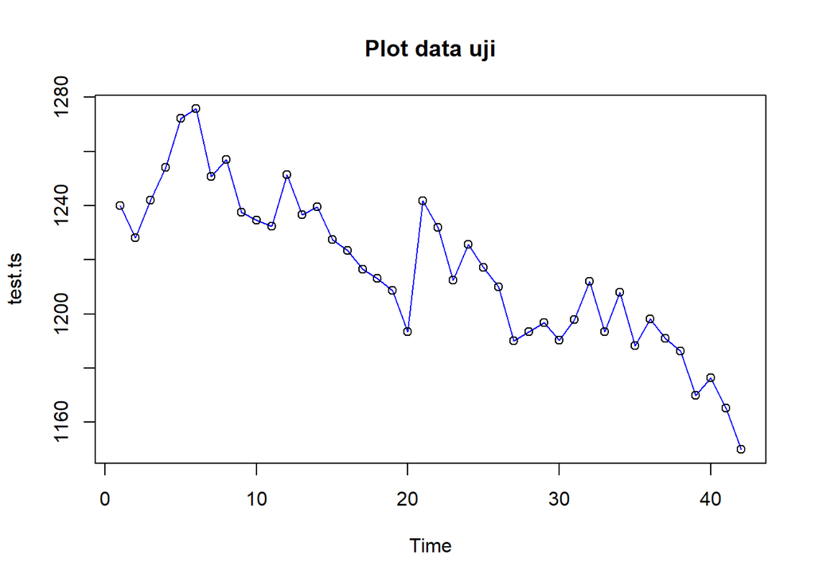

```r
plot(test.ts, col="blue",main="Plot data uji")
points(test.ts)
```

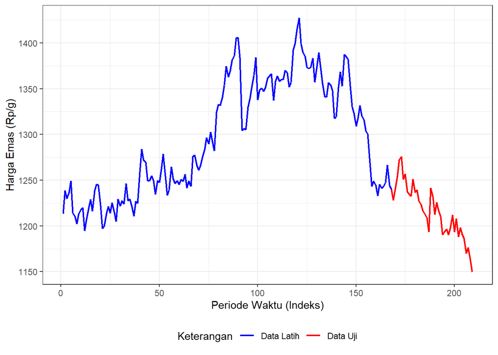

```r
train_df <- data.frame(
  Index = 1:length(train.ts),
  Harga = as.numeric(train.ts),
  status = "Data Latih"
)

test_df <- data.frame(
  Index = (length(train.ts) + 1):(length(train.ts) + length(test.ts)),
  Harga = as.numeric(test.ts),
  status = "Data Uji"
)

data_all <- rbind(train_df, test_df)

ggplot(data_all, aes(x = Index, y = Harga, color = status, group = 1)) +
  geom_line(size = 0.8) +
  labs(x = "Periode Waktu (Indeks)", y = "Harga Emas (Rp/g)", color = "Keterangan") +
  scale_color_manual(values = c("Data Latih" = "blue", "Data Uji" = "red")) +
  theme_bw() +
  theme(legend.position = "bottom")
```

# 5 Pemulusan

## 5.1 Single Moving Average (SMA)

```r
data.sma<-SMA(train.ts, n=4)
data.sma
```

```
## Time Series:
## Start = 1
## End = 167
## Frequency = 1
##   [1]       NA       NA       NA 1229.555 1238.633 1232.503 1227.628 1219.035
##   [9] 1210.007 1210.947 1213.367 1211.420 1209.922 1210.305 1212.575 1217.975
##  [17] 1225.747 1232.327 1236.182 1237.802 1227.520 1216.035 1208.335 1207.975
##  [25] 1212.187 1218.620 1219.002 1214.845 1218.697 1217.762 1220.845 1225.610
##  [33] 1229.797 1231.252 1231.670 1230.912 1222.065 1221.920 1220.720 1230.280
##  [41] 1248.522 1259.725 1271.007 1268.620 1259.985 1255.742 1250.595 1246.967
##  [49] 1247.062 1245.217 1248.377 1259.337 1260.530 1257.032 1251.442 1247.927
##  [57] 1247.207 1250.495 1253.082 1248.252 1248.032 1248.565 1250.310 1249.395
##  [65] 1249.002 1247.665 1252.462 1261.470 1265.765 1270.210 1267.852 1267.627
##  [73] 1271.935 1280.802 1286.555 1292.987 1295.130 1291.455 1300.230 1307.797
##  [81] 1317.722 1332.495 1339.882 1350.355 1358.072 1365.207 1371.987 1374.805
##  [89] 1385.480 1394.602 1395.330 1374.942 1350.235 1325.027 1311.550 1320.242
##  [97] 1331.480 1346.425 1359.887 1359.530 1358.695 1355.092 1345.850 1349.282
## [105] 1352.660 1355.995 1360.800 1357.165 1356.252 1356.325 1354.227 1359.970
## [113] 1360.420 1361.845 1364.150 1362.117 1361.495 1367.075 1375.177 1390.885
## [121] 1408.377 1410.137 1407.687 1400.405 1386.885 1380.142 1376.030 1375.512
## [129] 1371.540 1371.435 1375.465 1372.840 1372.502 1364.862 1352.782 1348.732
## [137] 1348.272 1349.952 1344.092 1334.745 1334.130 1339.190 1347.940 1365.037
## [145] 1373.402 1376.932 1376.910 1362.505 1347.050 1328.750 1320.157 1320.547
## [153] 1319.847 1321.567 1317.995 1310.255 1297.337 1279.120 1265.420 1251.350
## [161] 1242.422 1243.025 1240.990 1240.755 1244.247 1249.480 1250.300
```

```r
data.ramal<-c(NA,data.sma)
data.ramal
```

```
##   [1]       NA       NA       NA       NA 1229.555 1238.633 1232.503 1227.628
##   [9] 1219.035 1210.007 1210.947 1213.367 1211.420 1209.922 1210.305 1212.575
##  [17] 1217.975 1225.747 1232.327 1236.182 1237.802 1227.520 1216.035 1208.335
##  [25] 1207.975 1212.187 1218.620 1219.002 1214.845 1218.697 1217.762 1220.845
##  [33] 1225.610 1229.797 1231.252 1231.670 1230.912 1222.065 1221.920 1220.720
##  [41] 1230.280 1248.522 1259.725 1271.007 1268.620 1259.985 1255.742 1250.595
##  [49] 1246.967 1247.062 1245.217 1248.377 1259.337 1260.530 1257.032 1251.442
##  [57] 1247.927 1247.207 1250.495 1253.082 1248.252 1248.032 1248.565 1250.310
##  [65] 1249.395 1249.002 1247.665 1252.462 1261.470 1265.765 1270.210 1267.852
##  [73] 1267.627 1271.935 1280.802 1286.555 1292.987 1295.130 1291.455 1300.230
##  [81] 1307.797 1317.722 1332.495 1339.882 1350.355 1358.072 1365.207 1371.987
##  [89] 1374.805 1385.480 1394.602 1395.330 1374.942 1350.235 1325.027 1311.550
##  [97] 1320.242 1331.480 1346.425 1359.887 1359.530 1358.695 1355.092 1345.850
## [105] 1349.282 1352.660 1355.995 1360.800 1357.165 1356.252 1356.325 1354.227
## [113] 1359.970 1360.420 1361.845 1364.150 1362.117 1361.495 1367.075 1375.177
## [121] 1390.885 1408.377 1410.137 1407.687 1400.405 1386.885 1380.142 1376.030
## [129] 1375.512 1371.540 1371.435 1375.465 1372.840 1372.502 1364.862 1352.782
## [137] 1348.732 1348.272 1349.952 1344.092 1334.745 1334.130 1339.190 1347.940
## [145] 1365.037 1373.402 1376.932 1376.910 1362.505 1347.050 1328.750 1320.157
## [153] 1320.547 1319.847 1321.567 1317.995 1310.255 1297.337 1279.120 1265.420
## [161] 1251.350 1242.422 1243.025 1240.990 1240.755 1244.247 1249.480 1250.300
```

```r
n_test<-length(test.ts)
data.gab<-cbind(
  aktual=c(data.ts),
  pemulusan=c(data.sma,rep(NA,n_test)),
  ramalan=c(data.ramal,rep(data.ramal[length(data.ramal)],41)))

data.gab
```

```
##         aktual pemulusan  ramalan
##   [1,] 1213.07        NA       NA
##   [2,] 1238.55        NA       NA
##   [3,] 1229.90        NA       NA
##   [4,] 1236.70  1229.555       NA
##   [5,] 1249.38  1238.633 1229.555
##   [6,] 1214.03  1232.503 1238.633
##   [7,] 1210.40  1227.628 1232.503
##   [8,] 1202.33  1219.035 1227.628
##   [9,] 1213.27  1210.007 1219.035
##  [10,] 1217.79  1210.947 1210.007
##  [11,] 1220.08  1213.367 1210.947
##  [12,] 1194.54  1211.420 1213.367
##  [13,] 1207.28  1209.922 1211.420
##  [14,] 1219.32  1210.305 1209.922
```

[output cut: 195 more lines]

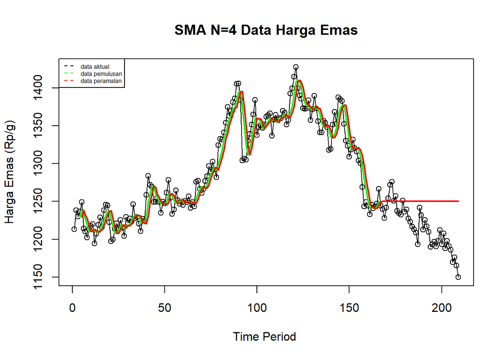

```r
ts.plot(data.ts, xlab="Time Period ", ylab="Harga Emas (Rp/g)", main= "SMA N=4 Data Harga Emas")
points(data.ts)
lines(data.gab[,2],col="green",lwd=2)
lines(data.gab[,3],col="red",lwd=2)
legend("topleft",c("data aktual","data pemulusan","data peramalan"), lty=8, col=c("black","green","red"), cex=0.5)
```

### 5.1.1 Akurasi Data Latih

```r
error_train.sma <- train.ts - data.ramal[1:length(train.ts)]
idx_sma <- 5:length(train.ts)

SSE_train.sma <- sum(error_train.sma[idx_sma]^2)
MSE_train.sma <- mean(error_train.sma[idx_sma]^2)
MAPE_train.sma <- mean(abs((error_train.sma[idx_sma] / train.ts[idx_sma]) * 100))

akurasi_train.sma <- matrix(c(SSE_train.sma, MSE_train.sma, MAPE_train.sma))
row.names(akurasi_train.sma) <- c("SSE", "MSE", "MAPE")
colnames(akurasi_train.sma) <- c("Akurasi m = 4")
akurasi_train.sma
```

```
##      Akurasi m = 4
## SSE   77276.105263
## MSE     474.086535
## MAPE      1.274026
```

### 5.1.2 Akurasi Data Uji

```r
ramalan_test.sma <- data.gab[(n_train + 1):n, 3]
error_test.sma <- test.ts - ramalan_test.sma

SSE_test.sma <- sum(error_test.sma^2)
MSE_test.sma <- mean(error_test.sma^2)
MAPE_test.sma <- mean(abs((error_test.sma / test.ts) * 100))

akurasi_test.sma <- matrix(c(SSE_test.sma, MSE_test.sma, MAPE_test.sma))
row.names(akurasi_test.sma) <- c("SSE", "MSE", "MAPE")
colnames(akurasi_test.sma) <- c("Akurasi m = 4")
akurasi_test.sma
```

```
##      Akurasi m = 4
## SSE   82822.696700
## MSE    1971.968969
## MAPE      3.083589
```

## 5.2 Double Moving Average (DMA)

```r
n_test <- length(test.ts)

data.sma <- SMA(train.ts, n = 4)
data.dma <- SMA(data.sma, n = 4)
At <- 2 * data.sma - data.dma
Bt <- (2 / (4 - 1)) * (data.sma - data.dma)

data.pemulusan <- At + Bt

data.ramal <- c(NA, data.pemulusan)

f <- At[length(At)] + Bt[length(Bt)] * (1:(n_test-1))

data.gab.dma <- cbind(
  aktual = c(data.ts),
  pemulusan = c(data.pemulusan, rep(NA, n_test)),
  ramalan = c(data.ramal, f)
)
data.gab.dma
```

```
##         aktual pemulusan  ramalan
##   [1,] 1213.07        NA       NA
##   [2,] 1238.55        NA       NA
##   [3,] 1229.90        NA       NA
##   [4,] 1236.70        NA       NA
##   [5,] 1249.38        NA       NA
##   [6,] 1214.03        NA       NA
##   [7,] 1210.40  1220.208       NA
##   [8,] 1202.33  1201.678 1220.208
##   [9,] 1213.27  1189.531 1201.678
##  [10,] 1217.79  1201.019 1189.531
##  [11,] 1220.08  1213.414 1201.019
##  [12,] 1194.54  1211.394 1213.414
##  [13,] 1207.28  1207.436 1211.394
##  [14,] 1219.32  1208.724 1207.436
```

[output cut: 195 more lines]

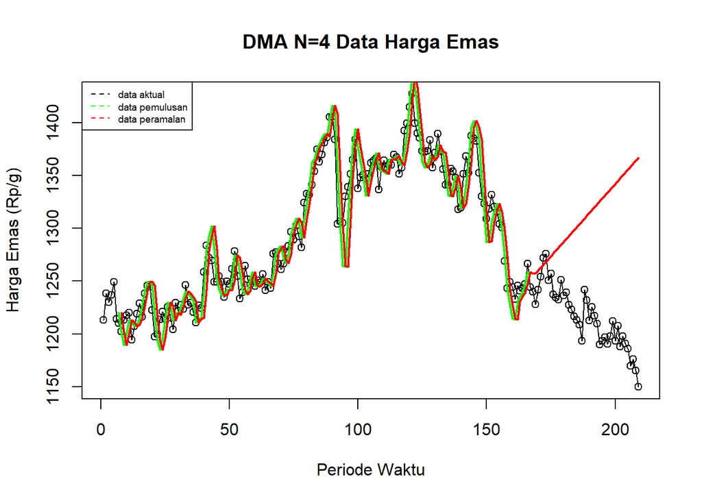

```r
ts.plot(data.ts, xlab="Periode Waktu", ylab="Harga Emas (Rp/g)", main= "DMA N=4 Data Harga Emas")
points(data.ts)
lines(data.gab.dma[,2],col="green",lwd=2)
lines(data.gab.dma[,3],col="red",lwd=2)
legend("topleft",c("data aktual","data pemulusan","data peramalan"), lty=8, col=c("black","green","red"), cex=0.6)
```

### 5.2.1 Akurasi Data Latih

```r
error_train.dma <- as.numeric(train.ts) - data.ramal[1:length(train.ts)]

idx_dma <- 8:length(train.ts)

SSE_train.dma <- sum(error_train.dma[idx_dma]^2, na.rm = TRUE)
MSE_train.dma <- mean(error_train.dma[idx_dma]^2, na.rm = TRUE)
MAPE_train.dma <- mean(abs((error_train.dma[idx_dma] / as.numeric(train.ts)[idx_dma]) * 100), na.rm = TRUE)

akurasi_train.dma <- matrix(c(SSE_train.dma, MSE_train.dma, MAPE_train.dma))
row.names(akurasi_train.dma) <- c("SSE", "MSE", "MAPE")
colnames(akurasi_train.dma) <- c("Akurasi m = 4")
akurasi_train.dma
```

```
##      Akurasi m = 4
## SSE   93713.048505
## MSE     585.706553
## MAPE      1.430832
```

### 5.2.2 Akurasi Data Uji

```r
ramalan_test.dma <- as.numeric(data.gab.dma[(n_train + 1):n, 3])
aktual_test.dma <- as.numeric(test.ts)

error_test.dma <- aktual_test.dma - ramalan_test.dma

SSE_test.dma <- sum(error_test.dma^2, na.rm = TRUE)
MSE_test.dma <- mean(error_test.dma^2, na.rm = TRUE)
MAPE_test.dma <- mean(abs((error_test.dma / aktual_test.dma) * 100), na.rm = TRUE)

akurasi_test.dma <- matrix(c(SSE_test.dma, MSE_test.dma, MAPE_test.dma))
row.names(akurasi_test.dma) <- c("SSE", "MSE", "MAPE")
colnames(akurasi_test.dma) <- c("Akurasi m = 4")
akurasi_test.dma
```

```
##      Akurasi m = 4
## SSE   5.239207e+05
## MSE   1.247430e+04
## MAPE  7.929323e+00
```

## 5.3 Single Exponential Smoothing

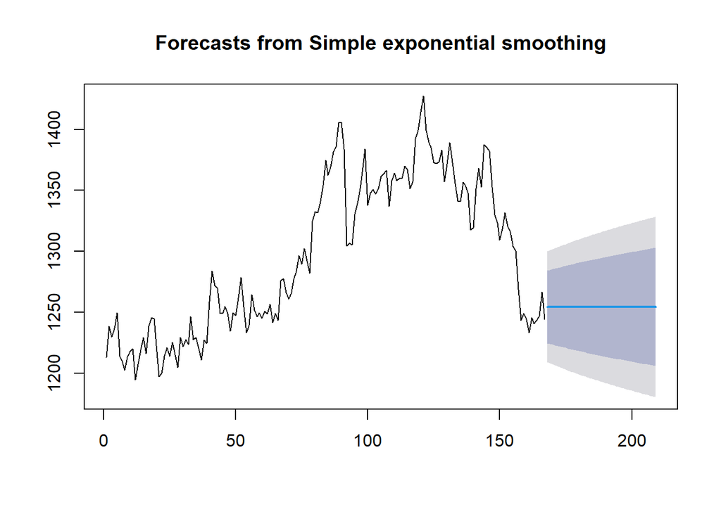

```r
ses1 <- ses(train.ts, h = 42, alpha = 0.2)
plot(ses1)
```

```r
ses1
```

```
##     Point Forecast    Lo 80    Hi 80    Lo 95    Hi 95
## 168       1254.464 1224.690 1284.238 1208.928 1300.000
## 169       1254.464 1224.100 1284.828 1208.026 1300.902
## 170       1254.464 1223.522 1285.406 1207.142 1301.786
## 171       1254.464 1222.954 1285.974 1206.273 1302.655
## 172       1254.464 1222.396 1286.532 1205.420 1303.508
## 173       1254.464 1221.848 1287.080 1204.582 1304.346
## 174       1254.464 1221.309 1287.619 1203.758 1305.171
## 175       1254.464 1220.778 1288.150 1202.946 1305.982
## 176       1254.464 1220.256 1288.672 1202.147 1306.781
## 177       1254.464 1219.742 1289.186 1201.361 1307.567
## 178       1254.464 1219.235 1289.693 1200.585 1308.343
## 179       1254.464 1218.735 1290.193 1199.821 1309.107
## 180       1254.464 1218.242 1290.686 1199.067 1309.861
## 181       1254.464 1217.756 1291.172 1198.324 1310.604
```

[output cut: 28 more lines]

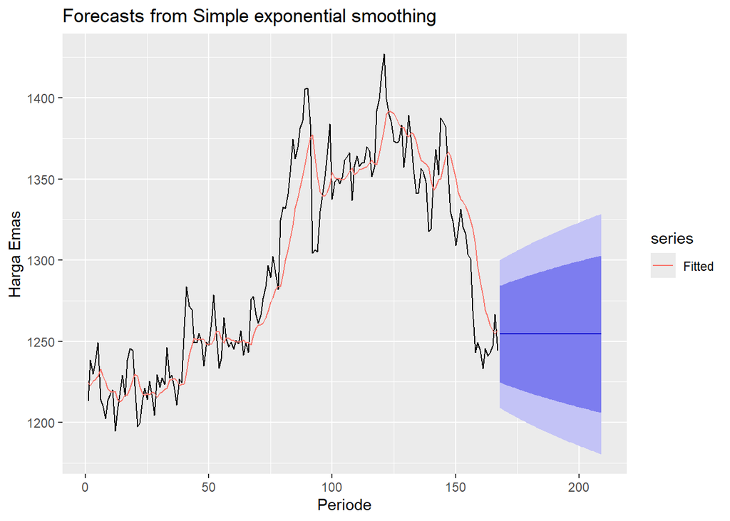

```r
autoplot(ses1) +
  autolayer(fitted(ses1), series="Fitted") +
  ylab("Harga Emas") + xlab("Periode")
```

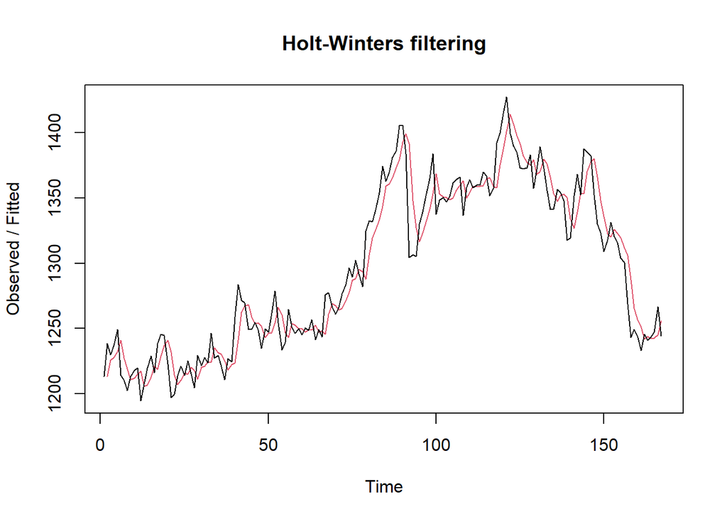

```r
ses2<- HoltWinters(train.ts, gamma = FALSE, beta = FALSE, alpha = 0.5)
plot(ses2)
```

```r
ramalan<- forecast(ses2, h=42)
ramalan
```

```
##     Point Forecast    Lo 80    Hi 80    Lo 95    Hi 95
## 168       1249.991 1226.397 1273.585 1213.907 1286.075
## 169       1249.991 1223.612 1276.370 1209.648 1290.335
## 170       1249.991 1221.094 1278.888 1205.797 1294.185
## 171       1249.991 1218.779 1281.203 1202.256 1297.726
## 172       1249.991 1216.624 1283.359 1198.960 1301.022
## 173       1249.991 1214.600 1285.383 1195.865 1304.118
## 174       1249.991 1212.685 1287.297 1192.937 1307.045
## 175       1249.991 1210.865 1289.118 1190.152 1309.830
## 176       1249.991 1209.125 1290.858 1187.491 1312.491
## 177       1249.991 1207.456 1292.526 1184.939 1315.043
## 178       1249.991 1205.850 1294.132 1182.484 1317.499
## 179       1249.991 1204.301 1295.681 1180.114 1319.868
## 180       1249.991 1202.803 1297.180 1177.823 1322.160
## 181       1249.991 1201.351 1298.632 1175.602 1324.381
```

[output cut: 28 more lines]

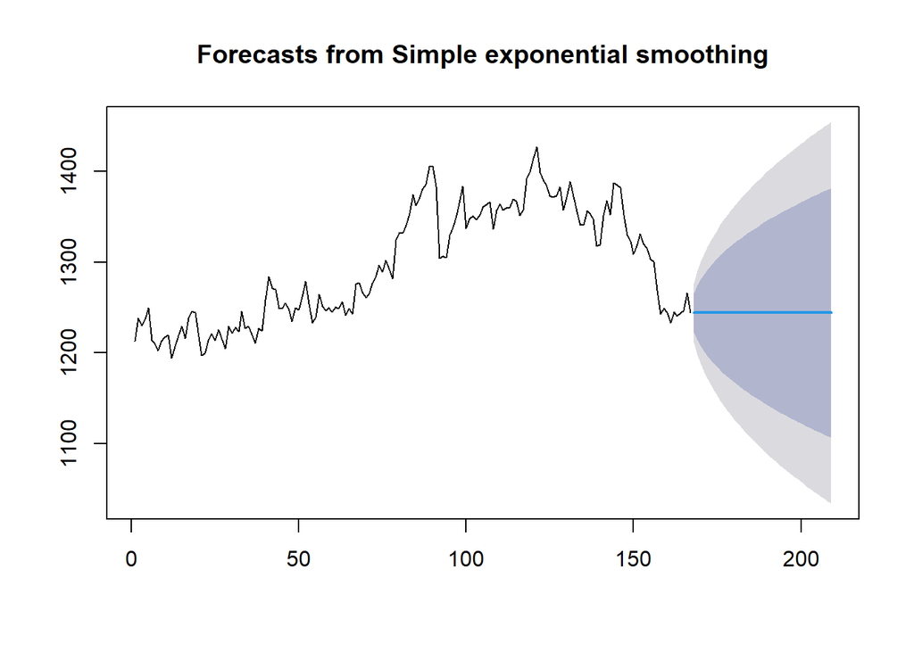

```r
ses.opt <- ses(train.ts, h = 42, alpha = NULL)
plot(ses.opt)
```

```r
ses.opt
```

```
##     Point Forecast    Lo 80    Hi 80    Lo 95    Hi 95
## 168       1244.242 1222.998 1265.486 1211.752 1276.732
## 169       1244.242 1214.200 1274.284 1198.297 1290.187
## 170       1244.242 1207.449 1281.035 1187.972 1300.512
## 171       1244.242 1201.758 1286.727 1179.268 1309.217
## 172       1244.242 1196.743 1291.741 1171.599 1316.886
## 173       1244.242 1192.210 1296.275 1164.665 1323.819
## 174       1244.242 1188.041 1300.444 1158.290 1330.195
## 175       1244.242 1184.161 1304.324 1152.355 1336.129
## 176       1244.242 1180.516 1307.968 1146.782 1341.703
## 177       1244.242 1177.069 1311.415 1141.510 1346.975
## 178       1244.242 1173.791 1314.694 1136.496 1351.989
## 179       1244.242 1170.658 1317.827 1131.705 1356.780
## 180       1244.242 1167.653 1320.831 1127.109 1361.375
## 181       1244.242 1164.762 1323.722 1122.688 1365.797
```

[output cut: 28 more lines]

```r
HWopt<- HoltWinters(train.ts, gamma = FALSE, beta = FALSE,alpha = NULL)
HWopt
```

```
## Holt-Winters exponential smoothing without trend and without seasonal component.
##
## Call:
## HoltWinters(x = train.ts, alpha = NULL, beta = FALSE, gamma = FALSE)
##
## Smoothing parameters:
##  alpha: 0.9999511
##  beta : FALSE
##  gamma: FALSE
##
## Coefficients:
##       [,1]
## a 1244.241
```

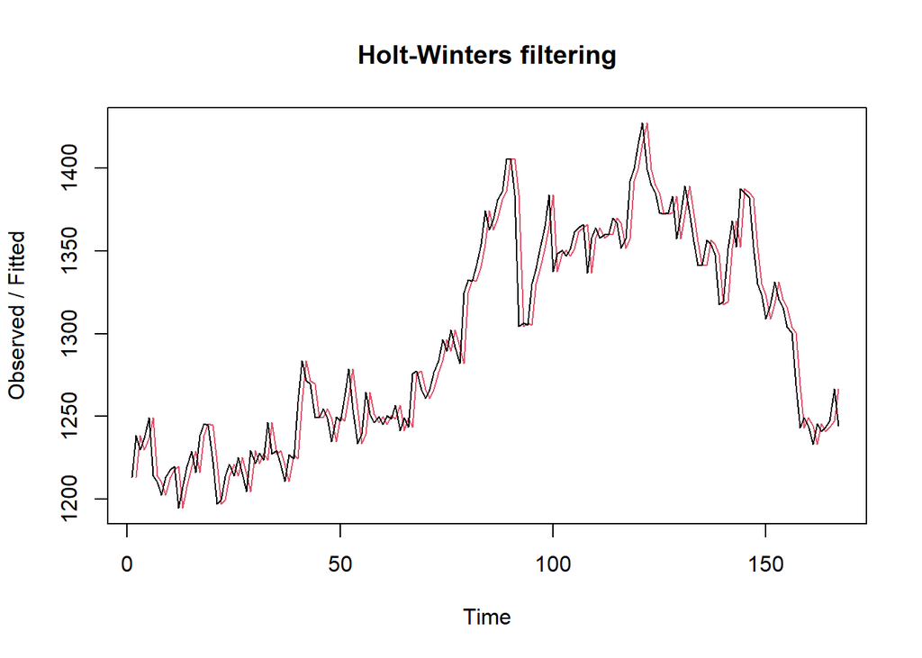

```r
plot(HWopt)
```

```r
ramalanopt<- forecast(HWopt, h=42)
ramalanopt
```

```
##     Point Forecast    Lo 80    Hi 80    Lo 95    Hi 95
## 168       1244.241 1222.999 1265.484 1211.753 1276.729
## 169       1244.241 1214.200 1274.282 1198.298 1290.184
## 170       1244.241 1207.449 1281.033 1187.973 1300.510
## 171       1244.241 1201.758 1286.725 1179.268 1309.214
## 172       1244.241 1196.743 1291.739 1171.599 1316.883
## 173       1244.241 1192.210 1296.272 1164.666 1323.816
## 174       1244.241 1188.041 1300.441 1158.290 1330.192
## 175       1244.241 1184.161 1304.322 1152.356 1336.126
## 176       1244.241 1180.516 1307.966 1146.782 1341.700
## 177       1244.241 1177.069 1311.413 1141.511 1346.972
## 178       1244.241 1173.791 1314.692 1136.496 1351.986
## 179       1244.241 1170.658 1317.824 1131.706 1356.777
## 180       1244.241 1167.653 1320.829 1127.110 1361.372
## 181       1244.241 1164.762 1323.720 1122.689 1365.793
```

[output cut: 28 more lines]

### 5.3.1 Akurasi Data Latih (HWopt)

```r
SSE<-HWopt$SSE
MSE<-HWopt$SSE/length(train.ts)
RMSE<-sqrt(MSE)

akurasi <- matrix(c(SSE,MSE,RMSE))
row.names(akurasi)<- c("SSE", "MSE", "RMSE")
colnames(akurasi) <- c("Akurasi Data Latih (HWopt)")
akurasi
```

```
##      Akurasi Data Latih (HWopt)
## SSE                 45339.96268
## MSE                   271.49678
## RMSE                   16.47716
```

```r
SSE <- HWopt$SSE
MSE <- HWopt$SSE / length(train.ts)
RMSE <- sqrt(MSE)

fitted <- as.numeric(HWopt$fitted[, 1])[1:length(train.ts)]
error_train <- as.numeric(train.ts) - fitted
MAPE <- mean(abs((error_train / as.numeric(train.ts)) * 100), na.rm = TRUE)

akurasi <- matrix(c(SSE, MSE, RMSE, MAPE), nrow = 4)
row.names(akurasi) <- c("SSE", "MSE", "RMSE", "MAPE")
colnames(akurasi) <- c("Akurasi Data Latih (HWopt)")
akurasi
```

```
##      Akurasi Data Latih (HWopt)
## SSE                4.533996e+04
## MSE                2.714968e+02
## RMSE               1.647716e+01
## MAPE               4.685727e-05
```

### 5.3.2 Akurasi Data Uji (HWopt)

```r
ramalan_test <- as.numeric(ramalanopt$mean)
error_test <- as.numeric(test.ts) - ramalan_test

SSE_test <- sum(error_test^2, na.rm = TRUE)
MSE_test <- mean(error_test^2, na.rm = TRUE)
RMSE_test <- sqrt(MSE_test)
MAPE_test <- mean(abs((error_test / as.numeric(test.ts)) * 100), na.rm = TRUE)

akurasi_test <- matrix(c(SSE_test, MSE_test, RMSE_test, MAPE_test), nrow = 4)
row.names(akurasi_test) <- c("SSE", "MSE", "RMSE", "MAPE")
colnames(akurasi_test) <- c("Akurasi Testing (HWopt)")
akurasi_test
```

```
##      Akurasi Testing (HWopt)
## SSE             67004.662433
## MSE              1595.349106
## RMSE               39.941822
## MAPE                2.722506
```

## 5.4 Double Exponential Smoothing (DES)

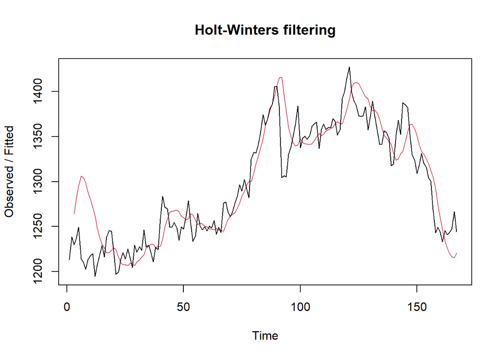

```r
des.1<- HoltWinters(train.ts, gamma = FALSE, beta = 0.2, alpha = 0.2)
plot(des.1)
```

```r
ramalandes1<- forecast(des.1, h=42)
ramalandes1
```

```
##     Point Forecast     Lo 80    Hi 80     Lo 95    Hi 95
## 168       1221.253 1184.4888 1258.017 1165.0269 1277.479
## 169       1217.139 1179.3310 1254.948 1159.3165 1274.962
## 170       1213.026 1173.8410 1252.210 1153.0979 1272.953
## 171       1208.912 1167.9993 1249.825 1146.3415 1271.482
## 172       1204.798 1161.7980 1247.798 1139.0351 1270.561
## 173       1200.684 1155.2392 1246.130 1131.1819 1270.187
## 174       1196.571 1148.3323 1244.809 1122.7965 1270.345
## 175       1192.457 1141.0921 1243.822 1113.9011 1271.013
## 176       1188.343 1133.5360 1243.150 1104.5228 1272.164
## 177       1184.230 1125.6830 1242.776 1094.6903 1273.769
## 178       1180.116 1117.5516 1242.680 1084.4321 1275.799
## 179       1176.002 1109.1597 1242.844 1073.7755 1278.229
## 180       1171.888 1100.5238 1243.253 1062.7458 1281.031
## 181       1167.775 1091.6591 1243.890 1051.3660 1284.183
```

[output cut: 28 more lines]

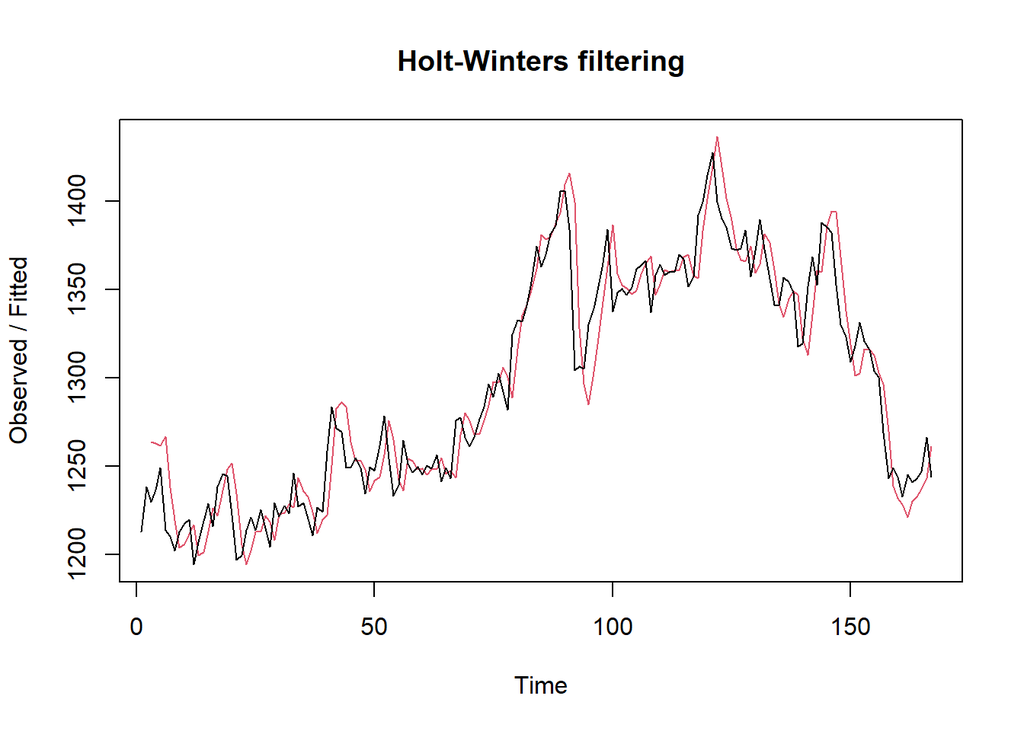

```r
des.2<- HoltWinters(train.ts, gamma = FALSE, beta = 0.3, alpha = 0.6)
plot(des.2)
```